# Quality checks on RDBFIS data formats

```r
library(RDBqc)
```

RDBqc allows to carry out a set of *a priori* quality checks on detailed sampling data and on aggregated landing data, and *a posteriori* quality checks on MEDBS, FDI and GFCM data call formats.

The supported quality checks in version 0.0.10 are:

### *A priori* quality checks

- RCG CS - biological sampling data
- RCG CL - aggregated landing data

### *A posteriori* quality checks

- MEDBS - catch data
- MEDBS - discard data
- MEDBS - landing data
- MEDBS - GP table
- MEDBS - LW table
- MEDBS - MA table
- MEDBS - ML table
- MEDBS - SA table
- MEDBS - SL table
- FDI tables (G, H, I and J)
- GFCM - Task II.2 table
- GFCM - Task III table
- GFCM - Task VII.2 table
- GFCM - Task VII.3.1 table
- GFCM - Task VII.3.2 table

# Checks on RCG

Example of Regional Coordination Group Mediterranean & Black Sea data formats:

**CS table**

```r
head(data_ex)
```

```
#>   Sampling_type Flag_country Year  Trip_code Harbour
#> 1             S          ITA 2016 01_18_2016   ITMOL
#> 2             S          ITA 2016 01_18_2016   ITMOL
#> 3             S          ITA 2016 01_18_2016   ITMOL
#> 4             S          ITA 2016 01_18_2016   ITMOL
#> 5             S          ITA 2016 01_18_2016   ITMOL
#> 6             S          ITA 2016 01_18_2016   ITMOL
#>   Number_of_sets_hauls_on_trip Days_at_sea Sampling.method Aggregation_level
#> 1                            4           1    SelfSampling              TRUE
#> 2                            4           1    SelfSampling              TRUE
#> 3                            4           1    SelfSampling              TRUE
#> 4                            4           1    SelfSampling              TRUE
#> 5                            4           1    SelfSampling              TRUE
#> 6                            4           1    SelfSampling              TRUE
#>   Station_number Duration_of_fishing_operation Initial_latitude
```

[output cut: 55 more lines]

**CL table**

```r
head(data_exampleCL)
```

```
#>   landCtry vslFlgCtry year quarter month  area rect subRect
#> 1       NA   COUNTRY1 1900       1     1 GSA99   NA      NA
#> 2       NA   COUNTRY1 1900       1     2 GSA99   NA      NA
#> 3       NA   COUNTRY1 1900       1     3 GSA99   NA      NA
#> 4       NA   COUNTRY1 1900       2     4 GSA99   NA      NA
#> 5       NA   COUNTRY1 1900       2     5 GSA99   NA      NA
#> 6       NA   COUNTRY1 1900       2     6 GSA99   NA      NA
#>                      taxon landCat commCatScl commCat  foCatNat foCatEu5
#> 1 Parapenaeus longirostris      NA         NA      NA OTB_shelf       NA
#> 2 Parapenaeus longirostris      NA         NA      NA OTB_shelf       NA
#> 3 Parapenaeus longirostris      NA         NA      NA OTB_shelf       NA
#> 4 Parapenaeus longirostris      NA         NA      NA OTB_shelf       NA
#> 5 Parapenaeus longirostris      NA         NA      NA OTB_shelf       NA
#> 6 Parapenaeus longirostris      NA         NA      NA OTB_shelf       NA
#>           foCatEu6 harbour vslLenCat unallocCatchWt misRepCatchWt    landWt
#> 1 OTB_DEF_>=40_0_0    Port        NA             NA            NA  73452.53
#> 2 OTB_DEF_>=40_0_0    Port        NA             NA            NA  78741.52
#> 3 OTB_DEF_>=40_0_0    Port        NA             NA            NA  82021.10
#> 4 OTB_DEF_>=40_0_0    Port        NA             NA            NA  89022.59
#> 5 OTB_DEF_>=40_0_0    Port        NA             NA            NA 103911.92
#> 6 OTB_DEF_>=40_0_0    Port        NA             NA            NA 102987.30
#>   landMult landValue
#> 1       NA  372658.8
#> 2       NA  392665.2
#> 3       NA  460280.8
#> 4       NA  433524.2
#> 5       NA  494103.4
#> 6       NA  498298.8
```

## Checks on CS

### check LFD

This function `RCG_check_LFD` returns an empty data frame if all the lengths collected are within the length range min_len-max_len; if some lengths are outside this range, the corresponding records are returned as a data frame.

```r
RCG_check_LFD(data_ex,MS="ITA",GSA="GSA99", SP="Mullus barbatus",min_len=6,max_len=250)[[1]]
```

```
#> [1] No individual length classes out of the expected range
#>  [1] Sampling_type
#>  [2] Flag_country
#>  [3] Year
#>  [4] Trip_code
#>  [5] Harbour
#>  [6] Number_of_sets_hauls_on_trip
#>  [7] Days_at_sea
#>  [8] Sampling.method
#>  [9] Aggregation_level
#> [10] Station_number
#> [11] Duration_of_fishing_operation
#> [12] Initial_latitude
#> [13] Initial_longitude
#> [14] Final_latitude
```

[output cut: 27 more lines]

A plot of the frequency distribution is also returned:

```r
RCG_check_LFD(data_ex,MS="ITA",GSA="GSA99", SP="Mullus barbatus",min_len=6,max_len=250)[[2]]
```

```
#> [1] No individual length classes out of the expected range
```

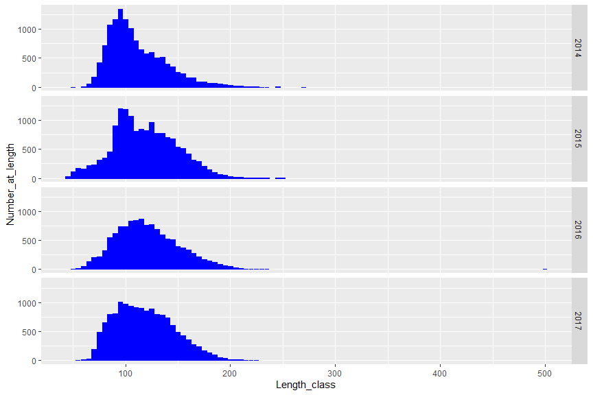

### check LFD by commercial categories

This function `RCG_check_LFD_comm_cat` reports for each year and commercial category the minimum and maximum lengths in the dataset.

```r
RCG_check_LFD_comm_cat(data_ex,MS="ITA",GSA="GSA99", SP="Mullus barbatus")[[1]]
```

```
#>    Year Commercial_size_category Min Max
#> 1  2014                        1  75 270
#> 2  2014                        2  60 205
#> 3  2014                        3  65 155
#> 4  2014                        S  50 130
#> 5  2015                        1  75 250
#> 6  2015                        2  45 195
#> 7  2015                        3  80 175
#> 8  2015                        S  45 140
#> 9  2016                        1  50 500
#> 10 2016                        2  70 190
#> 11 2016                        3  80 155
#> 12 2016                        S  50 130
#> 13 2017                        1  80 225
#> 14 2017                        2  70 205
#> 15 2017                        3  65 150
#> 16 2017                        S  55 130
```

A plot of the length distributions by year and commercial category is also returned:

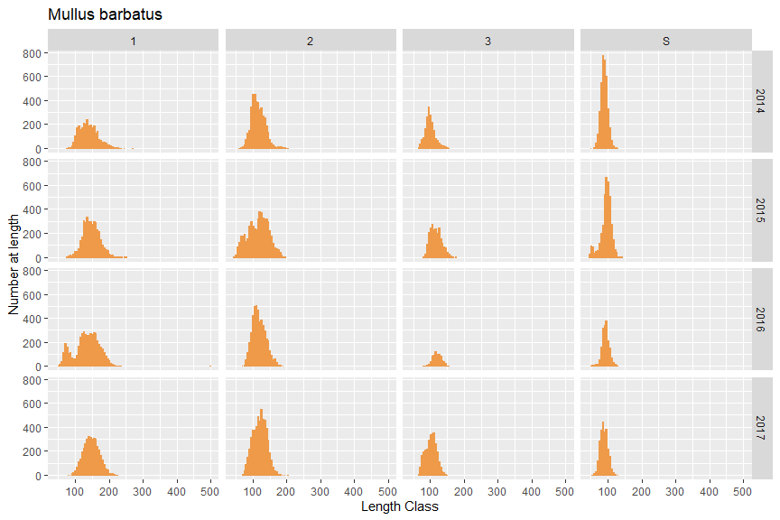

```r
RCG_check_LFD_comm_cat(data_ex,MS="ITA",GSA="GSA99", SP="Mullus barbatus")[[2]]
```

### Check AL

This function `RCG_check_AL` reports for each year and length class the number of age measurements in the dataset, providing a summary data frame.

```r
results <- RCG_check_AL(data_ex,MS="ITA",GSA="GSA99",SP="Mullus barbatus",min_age=0,max_age=5)[[1]]
```

```
#> NA included in the 'Age' field have been removed from the analysis.
#> NA included in the 'Length_class' field have been removed from the analysis.
```

```r
head(results)
```

```
#>   Year Length_class nb_age_measurements
#> 1 2015           45                   1
#> 2 2014           50                   1
#> 3 2015           50                   1
#> 4 2016           50                   1
#> 5 2015           55                   3
#> 6 2016           55                   1
```

Moreover, the function detects if the age data are in the range min_age-max_age, reporting the list of the trip codes including outliers.

```r
RCG_check_AL(data_ex,MS="ITA",GSA="GSA99",SP="Mullus barbatus",min_age=0,max_age=5)[[2]]
```

```
#> NA included in the 'Age' field have been removed from the analysis.
#> NA included in the 'Length_class' field have been removed from the analysis.
#>  [1] "01_18_2016" "02_18_2016" "05_18_2015" "07_18_2016" "08_18_2016"
#>  [6] "12_18_2015" "17_18_2014" "31_18_2017" "34_18_2016" "4_18_2014"
#> [11] "57_18_2017" "66_18_2017"
```

A plot of the age/length relationship by sex and year is outputted for the selected species

```r
RCG_check_AL(data_ex,MS="ITA",GSA="GSA99",SP="Mullus barbatus",min_age=0,max_age=5)[[3]]
```

```
#> NA included in the 'Age' field have been removed from the analysis.
#> NA included in the 'Length_class' field have been removed from the analysis.
```

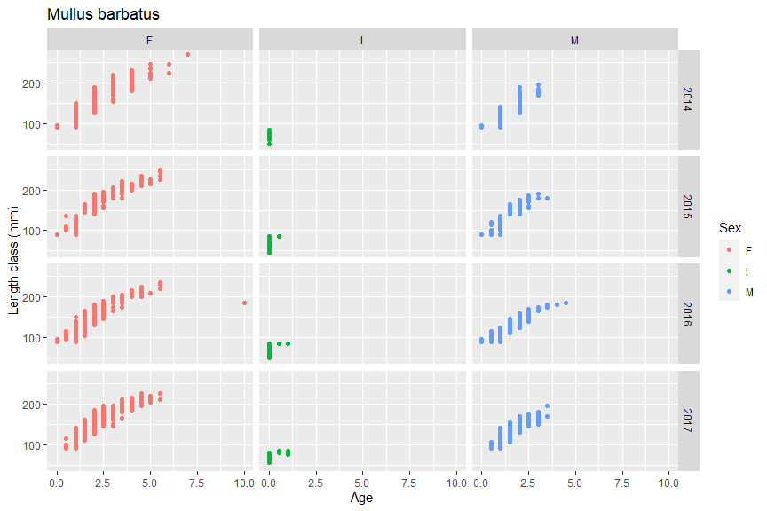

### Check lw

This function `RCG_check_lw` plots for each year and sex the length-weight scatter plot

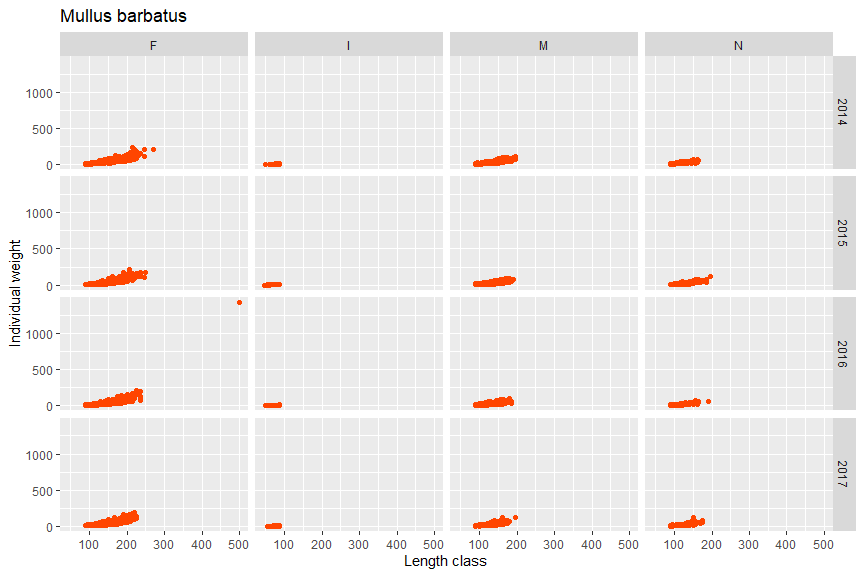

```r
RCG_check_lw(data_ex,MS="ITA",GSA="GSA99", SP="Mullus barbatus",Min=0,Max=200)[[2]]
```

Furthermore, it checks if the weight data are within the boundaries in input, providing the data frame of the records with the outliers

```r
RCG_check_lw(data_ex,MS="ITA",GSA="GSA99", SP="Mullus barbatus",Min=0,Max=200)[[1]]
```

```
#>      Sampling_type Flag_country Year  Trip_code Harbour
#> 1                S          ITA 2016 01_18_2016   ITMOL
#> 77               S          ITA 2016 02_18_2016   ITMOL
#> 2430             S          ITA 2014 12_18_2014   ITMOL
#> 5544             S          ITA 2014  4_18_2014   ITBDS
#> 5777             S          ITA 2015 43_18_2015   ITMOL
#> 7946             S          ITA 2014 87_18_2014   ITBDS
#> 7949             S          ITA 2014 87_18_2014   ITBDS
#>      Number_of_sets_hauls_on_trip Days_at_sea Sampling.method Aggregation_level
#> 1                               4           1    SelfSampling              TRUE
#> 77                              8           2        Observer              TRUE
#> 2430                            5           1    SelfSampling              TRUE
#> 5544                            7           2    SelfSampling              TRUE
#> 5777                            4           1        Observer              TRUE
#> 7946                            5           1        Observer              TRUE
```

[output cut: 73 more lines]

### check maturity stages

This function `RCG_check_mat` plots for each year and sex the length-maturity stage scatter plot

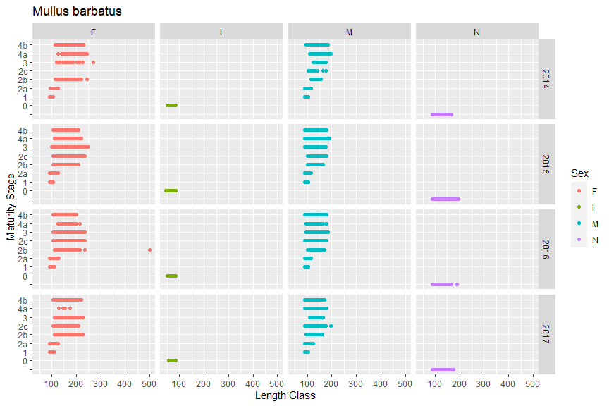

```r
RCG_check_mat(data_ex,MS="ITA",GSA="GSA99",SP="Mullus barbatus")
```

### check matutity ogive

This function `RCG_check_mat_ogive` plots the maturity ogive by sex derived from the dataset:

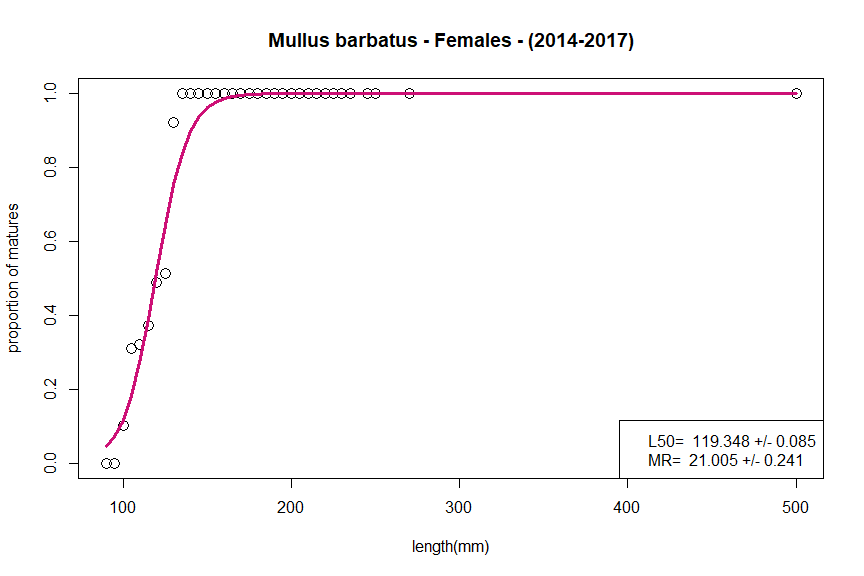

```r
RCG_check_mat_ogive(data_ex,MS="ITA",GSA="GSA99",SP="Mullus barbatus", sex="F",immature_stages=c("0","1","2a"))
```

### Summarize individual measurements

This function `RCG_summarize_ind_meas` reports for each trip the number of length sex, maturity, individual weight and age measurements for a selected species.

```r
results <- RCG_summarize_ind_meas(data=data_ex,MS="ITA",GSA="GSA99",SP="Mullus barbatus")
head(results)
```

```
#>   Year  Area         Species  Trip_code number_of_data            variable
#> 1 2014 GSA99 Mullus barbatus 12_18_2014            120 length_measurements
#> 2 2014 GSA99 Mullus barbatus 14_18_2014            163 length_measurements
#> 3 2014 GSA99 Mullus barbatus 15_18_2014            252 length_measurements
#> 4 2014 GSA99 Mullus barbatus 17_18_2014            239 length_measurements
#> 5 2014 GSA99 Mullus barbatus 19_18_2014           1657 length_measurements
#> 6 2014 GSA99 Mullus barbatus 20_18_2014            752 length_measurements
```

### Summarize trips

This function `RCG_summarize_trips` reports for the selected species the number of trips in the dataset for each year, area, harbour, metier and sampling method.

```r
results <- RCG_summarize_trips(data_ex,MS="ITA",GSA="GSA99",SP="Mullus barbatus")
head(results)
```

```
#>   Year  Area Harbour Fishing_activity_category_European_lvl_6 Sampling.method
#> 1 2014 GSA99   ITBCE                         OTB_DEF_>=40_0_0        Observer
#> 2 2014 GSA99   ITBDS                         OTB_DEF_>=40_0_0        Observer
#> 3 2014 GSA99   ITBDS                         OTB_DEF_>=40_0_0    SelfSampling
#> 4 2014 GSA99   ITMFR                         OTB_DEF_>=40_0_0        Observer
#> 5 2014 GSA99   ITMFR                         OTB_DEF_>=40_0_0    SelfSampling
#> 6 2014 GSA99   ITMNP                         OTB_DEF_>=40_0_0        Observer
#>   Nb_trips
#> 1        2
#> 2        2
#> 3        2
#> 4        1
#> 5        7
#> 6        2
```

### Check trips location

The function `RCG_check_loc` allows to check the spatial distribution of data using the initial and final coordinates, where available, and the ports position included in the data.

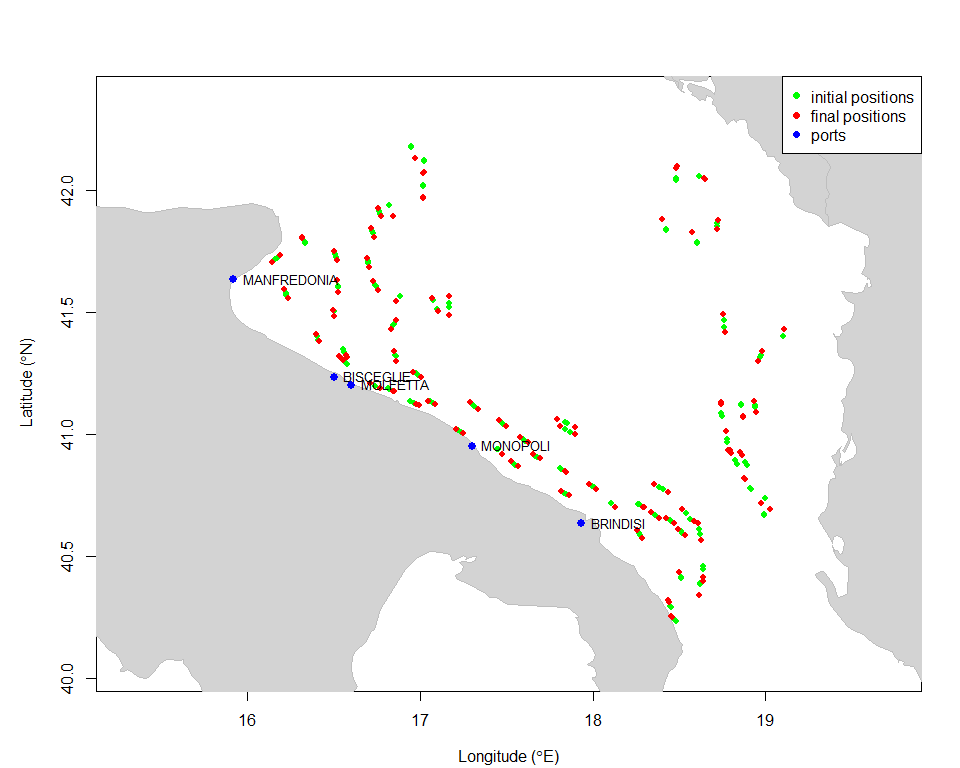

```r
RCG_check_loc(data_ex)
```

## Checks on CL

This function `RCG_check_CL` allows to check the data in the CL table for the selected species. The output is a list of 6 data frames:

1. Sum of Landings by year, quarter and month;

```r
RCG_check_CL(data_exampleCL,MS="COUNTRY1",GSA="GSA99",SP="Parapenaeus longirostris")[[1]]
```

```
#>    Year Quarter Month Sum_Landings
#> 1  1900       1     1     80553.10
#> 2  1900       1     2     80519.05
#> 3  1900       1     3     85107.68
#> 4  1900       2     4     90093.59
#> 5  1900       2     5    110096.34
#> 6  1900       2     6    117515.89
#> 7  1900       3     7     98584.85
#> 8  1900       3     8     49500.43
#> 9  1900       3     9     32084.59
#> 10 1900       4    10    153080.70
#> 11 1900       4    11    123574.70
#> 12 1900       4    12     99743.72
```

2. Sum of Landing value by year, quarter and month;

```r
RCG_check_CL(data_exampleCL,MS="COUNTRY1",GSA="GSA99",SP="Parapenaeus longirostris")[[2]]
```

```
#>    Year Quarter Month Sum_LandingsValue
#> 1  1900       1     1          410296.6
#> 2  1900       1     2          400928.4
#> 3  1900       1     3          476691.5
#> 4  1900       2     4          438991.9
#> 5  1900       2     5          521380.8
#> 6  1900       2     6          571712.2
#> 7  1900       3     7          518606.2
#> 8  1900       3     8          308576.7
#> 9  1900       3     9          161772.9
#> 10 1900       4    10          609361.4
#> 11 1900       4    11          576900.8
#> 12 1900       4    12          601217.8
```

3. Sum of landings by LandCtry, VslFlgCtry, Area, Rect, SubRect, Harbour;

```r
RCG_check_CL(data_exampleCL,MS="COUNTRY1",GSA="GSA99",SP="Parapenaeus longirostris")[[3]]
```

```
#>   LandCtry VslFlgCtry  Area Rect SubRect Harbour Sum_Landings
#> 1      999   COUNTRY1 GSA99  999     999    Port      1120455
```

4. Sum of landing value by LandCtry, VslFlgCtry, Area, Rect, SubRect, Harbour;

```r
RCG_check_CL(data_exampleCL,MS="COUNTRY1",GSA="GSA99",SP="Parapenaeus longirostris")[[4]]
```

```
#>   LandCtry VslFlgCtry  Area Rect SubRect Harbour Sum_LandingsValue
#> 1      999   COUNTRY1 GSA99  999     999    Port           5596437
```

5. Sum of landings by Year, Species, foCatEu5, foCatEu6;

```r
RCG_check_CL(data_exampleCL,MS="COUNTRY1",GSA="GSA99",SP="Parapenaeus longirostris")[[5]]
```

```
#>   Year                  Species foCatEu5         foCatEu6 Sum_Landings
#> 1 1900 Parapenaeus longirostris      999 OTB_DEF_>=40_0_0  1018083.081
#> 2 1900 Parapenaeus longirostris      999 OTB_DWS_>=40_0_0     1453.471
#> 3 1900 Parapenaeus longirostris      999 OTB_MDD_>=40_0_0   100918.089
```

6. Sum of landing value by Year, Species, foCatEu5, foCatEu6.

```r
RCG_check_CL(data_exampleCL,MS="COUNTRY1",GSA="GSA99",SP="Parapenaeus longirostris")[[6]]
```

```
#>   Year                  Species foCatEu5         foCatEu6 Sum_LandingsValue
#> 1 1900 Parapenaeus longirostris      999 OTB_DEF_>=40_0_0       5050728.907
#> 2 1900 Parapenaeus longirostris      999 OTB_DWS_>=40_0_0          7721.884
#> 3 1900 Parapenaeus longirostris      999 OTB_MDD_>=40_0_0        537986.519
```

7. Plot of the landings by year and foCatEu6

```r
RCG_check_CL(data_exampleCL,MS="COUNTRY1",GSA="GSA99",SP="Parapenaeus longirostris")[[7]]
```

```
#> geom_path: Each group consists of only one observation. Do you need to adjust
#> the group aesthetic?
```

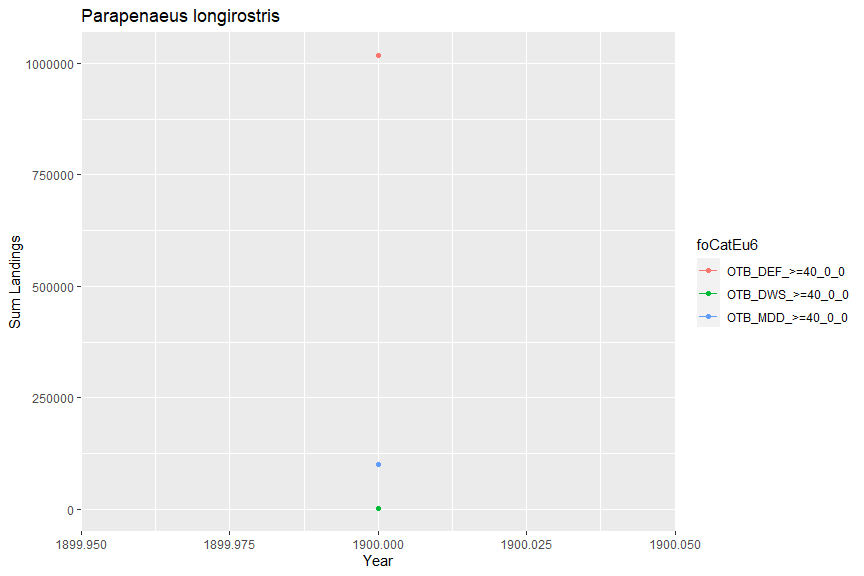

# Checks on MEDBS tables

*catch table*

```r
head(Catch_tab_example)
```

```
#>                              ID COUNTRY YEAR QUARTER VESSEL_LENGTH GEAR
#> 1       ITA 2008-1GNS-1DEMFSA 9     ITA 2008      -1            -1  GNS
#> 2   ITA 2010-1OTB50D100DWSPSA 9     ITA 2010      -1            -1  OTB
#> 3   ITA 2014-1OTB50D100DWSPSA 9     ITA 2014      -1            -1  OTB
#> 4  ITA 2008-1OTB50D100DEMSPSA 9     ITA 2008      -1            -1  OTB
#> 5 ITA 2008-1OTB50D100MDDWSPSA 9     ITA 2008      -1            -1  OTB
#> 6  ITA 2007-1OTB50D100DEMSPSA 9     ITA 2007      -1            -1  OTB
#>   MESH_SIZE_RANGE FISHERY  AREA SPECON SPECIES  LANDINGS DISCARDS
#> 1              -1    DEMF GSA 9     -1     DPS   0.50829       -1
#> 2          50D100    DWSP GSA 9     -1     DPS   9.69116       -1
#> 3          50D100    DWSP GSA 9     -1     DPS   2.11283       -1
#> 4          50D100   DEMSP GSA 9     -1     DPS 187.26219       -1
#> 5          50D100  MDDWSP GSA 9     -1     DPS  66.06531       -1
#> 6          50D100   DEMSP GSA 9     -1     DPS  89.84975       -1
#>   NO_SAMPLES_LANDINGS NO_LENGTH_MEASUREMENTS_LANDINGS
```

[output cut: 328 more lines]

*landings table*

```r
head(Landing_tab_example)
```

```
#>                             id country year quarter vessel_length gear
#> 1     ITA 2003 1GTR-1DEMSPSA 9     ITA 2003      -1            -1  GTR
#> 2      ITA 2003 1OTB50D100SA 9     ITA 2003      -1            -1  OTB
#> 3      ITA 2004-1GNS-1DEMFSA 9     ITA 2004      -1            -1  GNS
#> 4     ITA 2004-1GTR-1DEMSPSA 9     ITA 2004      -1            -1  GTR
#> 5 ITA 2004-1OTB50D100DEMSPSA 9     ITA 2004      -1            -1  OTB
#> 6     ITA 2005-1GTR-1DEMSPSA 9     ITA 2005      -1            -1  GTR
#>   mesh_size_range fishery  area specon species   landings unit lengthclass0
#> 1              -1   DEMSP GSA 9     -1     DPS   5.933227   mm            0
#> 2          50D100      -1 GSA 9     -1     DPS 316.615971   mm            0
#> 3              -1    DEMF GSA 9     -1     DPS   3.628830   mm            0
#> 4              -1   DEMSP GSA 9     -1     DPS   4.177760   mm            0
#> 5          50D100      -1 GSA 9     -1     DPS 367.431910   mm            0
#> 6              -1   DEMSP GSA 9     -1     DPS   0.517960   mm            0
#>   lengthclass1 lengthclass2 lengthclass3 lengthclass4 lengthclass5 lengthclass6
```

[output cut: 139 more lines]

*discards table*

```r
head(Discard_tab_example)
```

```
#>      id country year quarter vessel_length gear mesh_size_range fishery  area
#> 1 44554     ITA 2009      -1            -1  OTB          50D100   DEMSP GSA 9
#> 2 44571     ITA 2010      -1            -1  OTB          50D100   DEMSP GSA 9
#> 3 44583     ITA 2010      -1            -1  OTB          50D100  MDDWSP GSA 9
#> 4 44593     ITA 2011      -1            -1  OTB          50D100   DEMSP GSA 9
#> 5 44603     ITA 2011      -1            -1  OTB          50D100  MDDWSP GSA 9
#> 6 44612     ITA 2012      -1            -1  OTB          50D100   DEMSP GSA 9
#>   specon species  discards unit lengthclass0 lengthclass1 lengthclass2
#> 1     -1     DPS 38.355420   mm            0            0            0
#> 2     -1     DPS 24.396528   mm            0            0            0
#> 3     -1     DPS  2.703603   mm            0            0            0
#> 4     -1     DPS 60.519315   mm            0            0            0
#> 5     -1     DPS  2.743526   mm            0            0            0
#> 6     -1     DPS  6.571266   mm            0            0            0
#>   lengthclass3 lengthclass4 lengthclass5 lengthclass6 lengthclass7 lengthclass8
```

[output cut: 139 more lines]

## Checks on Catch table

### check duplicated records

The function `MEDBS_check_duplicates` checks the presence of duplicated rows in catch table

```r
catch_with_diplicate <- rbind(Catch_tab_example,Catch_tab_example[1,])
MEDBS_check_duplicates(data=catch_with_diplicate,type="c",MS="ITA",GSA="GSA 9",SP="DPS",verbose=TRUE)
```

```
#> There is/are 1 replicated row/rows in the data.
#>                         ID COUNTRY YEAR QUARTER VESSEL_LENGTH GEAR
#> 58 ITA 2008-1GNS-1DEMFSA 9     ITA 2008      -1            -1  GNS
#>    MESH_SIZE_RANGE FISHERY  AREA SPECON SPECIES LANDINGS DISCARDS
#> 58              -1    DEMF GSA 9     -1     DPS  0.50829        0
#>    NO_SAMPLES_LANDINGS NO_LENGTH_MEASUREMENTS_LANDINGS
#> 58                  30                               0
#>    NO_AGE_MEASUREMENTS_LANDINGS NO_SAMPLES_DISCARDS
#> 58                            0                   0
#>    NO_LENGTH_MEASUREMENTS_DISCARDS NO_AGE_MEASUREMENTS_DISCARDS
#> 58                              -1                           -1
#>    NO_SAMPLES_CATCH NO_LENGTH_MEASUREMENTS_CATCH NO_AGE_MEASUREMENTS_CATCH
#> 58               -1                           -1                        -1
#>    MIN_AGE MAX_AGE
#> 58      -1      -1
```

### Check catches coverage

The function `MEDBS_Catch_coverage` allows to check the coverage in Catch table by mean of summary tables summarizing both landing and discard volumes and producing relative plots for the selected species. In particular:

1. summary table of landings

```r
results <- suppressMessages(MEDBS_Catch_coverage(Catch_tab_example,"DPS","ITA","GSA 9"))
head(results[[1]])
```

```
#>   COUNTRY YEAR QUARTER VESSEL_LENGTH GEAR MESH_SIZE_RANGE FISHERY  AREA SPECIES
#> 1     ITA 2004      -1            -1  OTB          50D100      -1 GSA 9     DPS
#> 2     ITA 2004      -1            -1  GNS              -1    DEMF GSA 9     DPS
#> 3     ITA 2007      -1            -1  GNS              -1    DEMF GSA 9     DPS
#> 4     ITA 2008      -1            -1  GNS              -1    DEMF GSA 9     DPS
#> 5     ITA 2014      -1            -1  GNS              -1    DEMF GSA 9     DPS
#> 6     ITA 2017       2            -1  GNS              -1    DEMF GSA 9     DPS
#>    LANDINGS
#> 1 367.43191
#> 2   3.62883
#> 3   2.26308
#> 4   0.50829
#> 5   0.02736
#> 6   0.02688
```

2. summary table of discards

```r
head(results[[2]])
```

```
#>    COUNTRY YEAR QUARTER VESSEL_LENGTH GEAR MESH_SIZE_RANGE FISHERY  AREA
#> 5      ITA 2014      -1            -1  GNS              -1    DEMF GSA 9
#> 6      ITA 2017       2            -1  GNS              -1    DEMF GSA 9
#> 7      ITA 2003      -1            -1  GTR              -1   DEMSP GSA 9
#> 10     ITA 2012      -1            -1  GTR              -1   DEMSP GSA 9
#> 11     ITA 2003      -1            -1  OTB              -1   DEMSP GSA 9
#> 13     ITA 2006      -1            -1  OTB          50D100   DEMSP GSA 9
#>    SPECIES DISCARDS
#> 5      DPS        0
#> 6      DPS        0
#> 7      DPS        0
#> 10     DPS        0
#> 11     DPS        0
#> 13     DPS        0
```

3. Plot of landing volumes in catch table

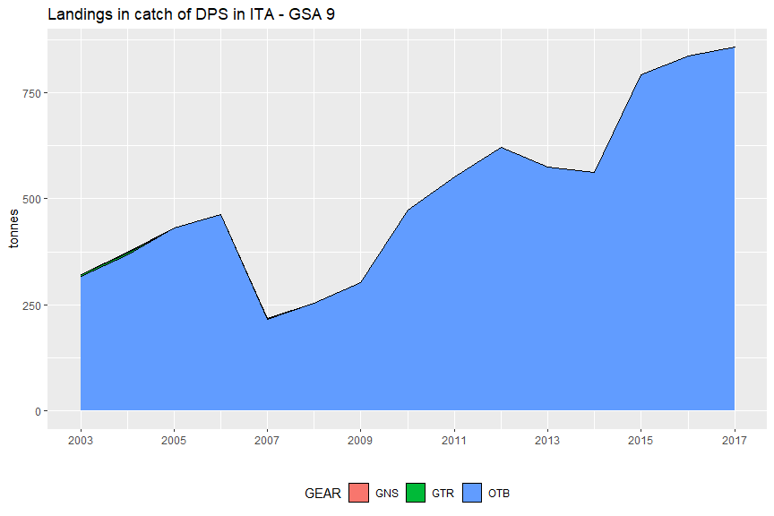

```r
results[[3]]
```

4. Plot of discard volumes in catch table

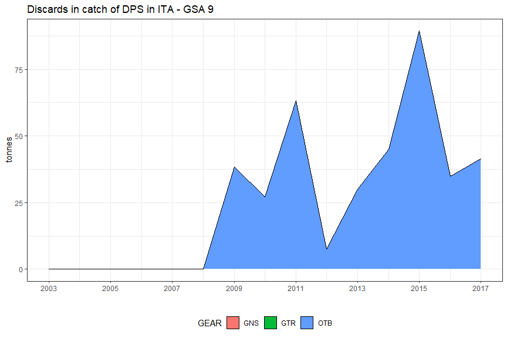

```r
results[[4]]
```

### check Sum of products (SOP)

The function checks if the percentage difference between SOP and both volumes of landing and discard are greater then a threshold value. The default value is fixed to 5%.

threshold = 5

```r
MEDBS_SOP(data=Catch_tab_example,SP="DPS",MS="ITA",GSA="GSA 9",threshold = 5)
```

```
#>    COUNTRY YEAR QUARTER VESSEL_LENGTH GEAR MESH_SIZE_RANGE FISHERY  AREA
#> 24     ITA 2009      -1            -1  OTB          50D100   DEMSP GSA 9
#> 25     ITA 2014      -1            -1  OTB          50D100   DEMSP GSA 9
#> 54     ITA 2017       4            -1  OTB          50D100   DEMSP GSA 9
#>    SPECIES check_LANDING check_DISCARD
#> 24     DPS                        7.68
#> 25     DPS                        5.53
#> 54     DPS                        7.73
```

threshold = 2

```r
MEDBS_SOP(data=Catch_tab_example,SP="DPS",MS="ITA",GSA="GSA 9",threshold = 2)
```

```
#>    COUNTRY YEAR QUARTER VESSEL_LENGTH GEAR MESH_SIZE_RANGE FISHERY  AREA
#> 11     ITA 2004      -1            -1  OTB          50D100      -1 GSA 9
#> 21     ITA 2011      -1            -1  OTB          50D100   DEMSP GSA 9
#> 24     ITA 2009      -1            -1  OTB          50D100   DEMSP GSA 9
#> 25     ITA 2014      -1            -1  OTB          50D100   DEMSP GSA 9
#> 30     ITA 2017       1            -1  OTB          50D100   DEMSP GSA 9
#> 32     ITA 2017       4            -1  OTB          50D100  MDDWSP GSA 9
#> 40     ITA 2016       3            -1  OTB          50D100  MDDWSP GSA 9
#> 43     ITA 2016       3            -1  OTB          50D100   DEMSP GSA 9
#> 44     ITA 2012      -1            -1  OTB          50D100  MDDWSP GSA 9
#> 54     ITA 2017       4            -1  OTB          50D100   DEMSP GSA 9
#>    SPECIES check_LANDING check_DISCARD
#> 11     DPS          2.98
#> 21     DPS                        4.96
#> 24     DPS         -3.62          7.68
#> 25     DPS                        5.53
#> 30     DPS         -3.37          2.07
#> 32     DPS          2.05
#> 40     DPS          2.84
#> 43     DPS                        3.29
#> 44     DPS                        3.88
#> 54     DPS          2.89          7.73
```

## Checks on discard and landing tables

### check duplicated records

The function `MEDBS_check_duplicates` checks the presence of duplicated rows in landings

```r
Landing_tab_example <- rbind(Landing_tab_example,Landing_tab_example[1,])
MEDBS_check_duplicates(data=Landing_tab_example,type="l",MS="ITA",GSA="GSA 9",SP="DPS",verbose=TRUE)
```

```
#> There is/are 1 replicated row/rows in the data.
#>                          ID COUNTRY YEAR QUARTER VESSEL_LENGTH GEAR
#> 58 ITA 2003 1GTR-1DEMSPSA 9     ITA 2003      -1            -1  GTR
#>    MESH_SIZE_RANGE FISHERY  AREA SPECON SPECIES LANDINGS
#> 58              -1   DEMSP GSA 9     -1     DPS 5.933227
```

The function `MEDBS_check_duplicates` also checks the presence of duplicated rows in discard

```r
Discard_tab_example <- rbind(Discard_tab_example,Discard_tab_example[1,])
MEDBS_check_duplicates(data=Discard_tab_example,type="d",MS="ITA",GSA="GSA 9",SP="DPS",verbose=TRUE)
```

```
#> There is/are 1 replicated row/rows in the data.
#>       ID COUNTRY YEAR QUARTER VESSEL_LENGTH GEAR MESH_SIZE_RANGE FISHERY  AREA
#> 22 44554     ITA 2009      -1            -1  OTB          50D100   DEMSP GSA 9
#>    SPECON SPECIES DISCARDS
#> 22     -1     DPS 38.35542
```

## Kolmogorov-Smirnov test

The function `MEDBS_ks` allows to perform the Kolmogorov-Smirnov test on both landings and discards for a selected species. The function performs Kolmogorov-Smirnov tests on couples of years to assess if they belong to the same population, returning a summary data frame. The function returns also the cumulative length distribution plots by fishery and year.

```r
ks <- MEDBS_ks(data=Landing_tab_example, type="l", SP="DPS",MS="ITA",GSA="GSA 9",Rt=1)
```

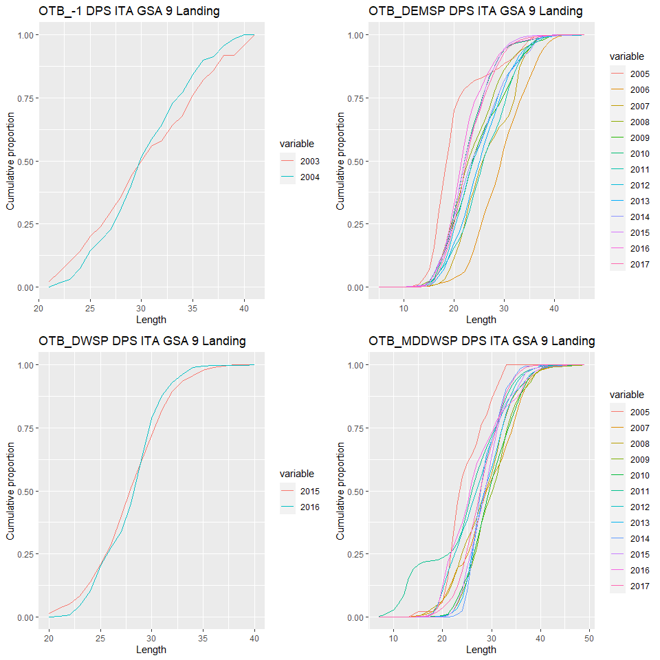

```r
results <- ks[[1]]
head(results)
```

```
#>            Group  NTot_yr1  NTot_yr2  Dmax      Dcalc H0_p0.05
#> Ds  2003 vs 2004 18516.419 22257.632 0.091 0.01720759 rejected
#> Ds1 2005 vs 2006  6167.447  3434.857 0.728 0.03683212 rejected
#> Ds2 2005 vs 2007  6167.447  7099.281 0.589 0.03011398 rejected
#> Ds3 2005 vs 2008  6167.447 19314.227 0.415 0.02530281 rejected
#> Ds4 2005 vs 2009  6167.447 22104.507 0.445 0.02491328 rejected
#> Ds5 2005 vs 2010  6167.447 36354.889 0.407 0.02382432 rejected
#>                           Comment        ID
#> Ds  not belong to same population    OTB_-1
#> Ds1 not belong to same population OTB_DEMSP
#> Ds2 not belong to same population OTB_DEMSP
#> Ds3 not belong to same population OTB_DEMSP
#> Ds4 not belong to same population OTB_DEMSP
#> Ds5 not belong to same population OTB_DEMSP
```

```r
# plot(ks[[3]])
```

### Check consistency of length data

The function `MEDBS_length_ind` allows to check the consistency of length data for a selected species on both landings and discards returning a summary table of the main length size indicators time series by fishery.

```r
results <- MEDBS_length_ind(Discard_tab_example,type="d",SP="DPS",MS=c("ITA"),GSA=c("GSA 9"), splines=c(0.2,0.4,0.6,0.8),Xtresholds = c(0.25,0.5,0.75))
head(results[[1]])
```

```
#>   year gear fishery total_number min_size mean_size max_size  sd_size spline
#> 1 2009  OTB   DEMSP     22633.62        8  16.18669       35 3.691644    0.2
#> 2 2009  OTB   DEMSP     22633.62        8  16.18669       35 3.691644    0.2
#> 3 2009  OTB   DEMSP     22633.62        8  16.18669       35 3.691644    0.2
#> 4 2009  OTB   DEMSP     22633.62        8  16.18669       35 3.691644    0.4
#> 5 2009  OTB   DEMSP     22633.62        8  16.18669       35 3.691644    0.4
#> 6 2009  OTB   DEMSP     22633.62        8  16.18669       35 3.691644    0.4
#>   percentile percentile_value
#> 1       0.25         12.97333
#> 2       0.50         15.37941
#> 3       0.75         18.07179
#> 4       0.25         10.17795
#> 5       0.50         14.99112
#> 6       0.75         19.41598
```

A plot of the time series of mean length in discards and landings is returned.

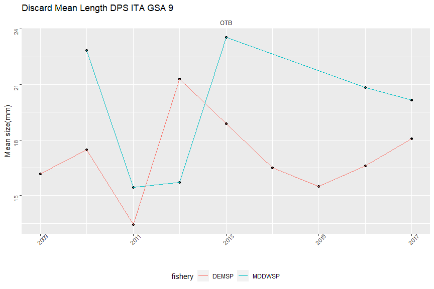

```r
results[[2]]
```

A plot of the time series of median length in discards and landings is returned.

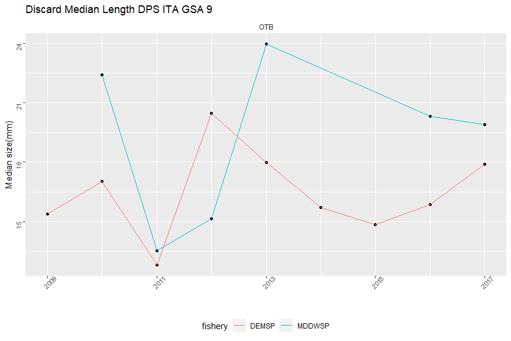

```r
results[[3]]
```

### Check of null individuals in landings and discards

The function `MEDBS_lengthclass_0` checks landings and discards for the presence of length class filled in having weigth > 0, returning a data frame with the rows with 0 values length class having weigth > 0.

```r
results <- MEDBS_lengthclass_0(data=Landing_tab_example,type="l",SP="DPS",MS="ITA",GSA="GSA 9",verbose=TRUE)
```

```
#> 17 cases in which length class number are zero and landings > 0
```

```r
head(results)
```

```
#>                               id country year quarter vessel_length gear
#> 1       ITA 2003 1GTR-1DEMSPSA 9     ITA 2003      -1            -1  GTR
#> 3        ITA 2004-1GNS-1DEMFSA 9     ITA 2004      -1            -1  GNS
#> 4       ITA 2004-1GTR-1DEMSPSA 9     ITA 2004      -1            -1  GTR
#> 6       ITA 2005-1GTR-1DEMSPSA 9     ITA 2005      -1            -1  GTR
#> 10 ITA 2006-1OTB50D100MDDWSPSA 9     ITA 2006      -1            -1  OTB
#> 11       ITA 2007-1GNS-1DEMFSA 9     ITA 2007      -1            -1  GNS
#>    mesh_size_range fishery  area specon species   landings ck_0_length
#> 1               -1   DEMSP GSA 9     -1     DPS   5.933227           0
#> 3               -1    DEMF GSA 9     -1     DPS   3.628830           0
#> 4               -1   DEMSP GSA 9     -1     DPS   4.177760           0
#> 6               -1   DEMSP GSA 9     -1     DPS   0.517960           0
#> 10          50D100  MDDWSP GSA 9     -1     DPS 407.103060           0
#> 11              -1    DEMF GSA 9     -1     DPS   2.263080           0
```

### weight 0 in landings and discards

The function `MEDBS_weight_0` checks landings or discards in weight equal to 0 having length classes filled in, returning the number of rows with 0 values in weights having length classes filled in.

```r
MEDBS_weight_0(data=Discard_tab_example,type="d",SP="DPS",MS="ITA",GSA="GSA 9", verbose=TRUE)
```

```
#> There aren't 0 discards
#> [1] 0
```

### weight -1 in landings and discards

The function `MEDBS_weight_minus1` checks landings in weight equal to -1 having length class filled in, returning the number of rows with -1 values in landing weights having length class filled in.

```r
MEDBS_weight_minus1(data=Discard_tab_example,type="d",SP="DPS",MS="ITA",GSA="GSA 9",verbose=TRUE)
```

```
#> There aren't -1 discards
#> [1] 0
```

### Years with missing length distributions

The function `MEDBS_yr_missing_length` checks the presence of years with missing length distributions in both landings and discards for a selected species. A data frame of the missing length distributions is returned.

```r
results <- MEDBS_yr_missing_length(data=Landing_tab_example,type="l",SP="DPS",MS="ITA",GSA="GSA 9")
head(results)
```

```
#>   year gear fishery total_number_landed
#> 1 2003  GTR   DEMSP                   0
#> 2 2004  GNS    DEMF                   0
#> 3 2004  GTR   DEMSP                   0
#> 4 2005  GTR   DEMSP                   0
#> 5 2006  OTB  MDDWSP                   0
#> 6 2007  GNS    DEMF                   0
```

## Checks on landings

### Comparison between landings in weight by quarter accounting for vessel length

The function `MEDBS_comp_land_Q_VL` allows to perform the comparison of landings of a selected species aggregated by quarters accounting for the presence of vessel length. A dataframe for the comparison of landings aggregated by quarters accounting for the presence of vessel length information is returned.

```r
results <- suppressMessages(MEDBS_comp_land_Q_VL(data = Landing_tab_example,
           SP = "DPS", MS = "ITA", GSA = "GSA 9"))
head(results)
```

```
#>   YEAR GEAR QUARTER    tot_VL tot_NoVL ratio
#> 1 2003  GTR      -1  11.86645       NA    NA
#> 2 2003  OTB      -1 316.61597       NA    NA
#> 3 2004  GNS      -1   3.62883       NA    NA
#> 4 2004  GTR      -1   4.17776       NA    NA
#> 5 2004  OTB      -1 367.43191       NA    NA
#> 6 2005  GTR      -1   0.51796       NA    NA
```

### Comparison between landings in weight by quarter and fishery accounting for vessel length

The function `MEDBS_comp_land_Q_VL_fishery` allows to perform the comparison of landings of a selected species aggregated by quarters and fishery accounting for the presence of vessel length. The function returns a data frame for the comparison of landings aggregated by quarters and fishery accounting for the presence of vessel length information.

```r
results <- suppressMessages(MEDBS_comp_land_Q_VL_fishery(data = Landing_tab_example,
        MS = "ITA", GSA = "GSA 9", SP = "DPS"))
head(results)
```

```
#>   YEAR GEAR FISHERY QUARTER    tot_VL tot_NoVL ratio
#> 1 2003  GTR   DEMSP      -1  11.86645       NA    NA
#> 2 2003  OTB      -1      -1 316.61597       NA    NA
#> 3 2004  GNS    DEMF      -1   3.62883       NA    NA
#> 4 2004  GTR   DEMSP      -1   4.17776       NA    NA
#> 5 2004  OTB      -1      -1 367.43191       NA    NA
#> 6 2005  GTR   DEMSP      -1   0.51796       NA    NA
```

### Comparison between landings in weight by quarter and -1

The function `MEDBS_comp_land_YQ` allows to perform the comparison of landings of a selected species aggregated by quarters and by year. The function returns a data frame for the comparison of landings aggregated by quarters and by year.

```r
MEDBS_comp_land_YQ(data=Landing_tab_example,SP="DPS",MS="ITA",GSA="GSA 9")
```

```
#>    YEAR GEAR     tot_q    tot_yr  ratio
#> 1  2003  GTR        NA  11.86645     NA
#> 2  2003  OTB        NA 316.61597     NA
#> 3  2004  GNS        NA   3.62883     NA
#> 4  2004  GTR        NA   4.17776     NA
#> 5  2004  OTB        NA 367.43191     NA
#> 6  2005  GTR        NA   0.51796     NA
#> 7  2005  OTB        NA 430.42544     NA
#> 8  2006  OTB        NA 462.40605     NA
#> 9  2007  GNS        NA   2.26308     NA
#> 10 2007  OTB        NA 215.16790     NA
#> 11 2008  GNS        NA   0.50829     NA
#> 12 2008  OTB        NA 253.49215     NA
#> 13 2009  OTB        NA 303.14069     NA
#> 14 2010  OTB        NA 473.29438     NA
#> 15 2011  OTB        NA 551.03147     NA
#> 16 2012  GTR        NA   0.16116     NA
#> 17 2012  OTB        NA 621.08818     NA
#> 18 2013  OTB        NA 575.66107     NA
#> 19 2014  GNS        NA   0.02736     NA
#> 20 2014  OTB        NA 561.43756     NA
#> 21 2015  OTB        NA 791.44936     NA
#> 22 2016  OTB 825.13200  10.47800 78.749
#> 23 2017  GNS   0.02688        NA     NA
#> 24 2017  OTB 856.80650        NA     NA
```

### Comparison between landings in weight by quarter, quarter -1 and by fishery

The function `MEDBS_comp_land_YQ_fishery` allows to perform the comparison of landings of a selected species aggregated by quarters and by year and fishery. The function returns a data frame for the comparison of landings aggregated by quarters and by year and fishery.

```r
results <- suppressMessages(MEDBS_comp_land_YQ_fishery(data = Landing_tab_example, SP = "DPS", MS = "ITA", GSA = "GSA 9"))
head(results)
```

```
#>   YEAR GEAR FISHERY tot_q    tot_yr ratio
#> 1 2003  GTR   DEMSP    NA  11.86645    NA
#> 2 2003  OTB      -1    NA 316.61597    NA
#> 3 2004  GNS    DEMF    NA   3.62883    NA
#> 4 2004  GTR   DEMSP    NA   4.17776    NA
#> 5 2004  OTB      -1    NA 367.43191    NA
#> 6 2005  GTR   DEMSP    NA   0.51796    NA
```

### Check mean weight by year,gear and fishery aggregation

The function `MEDBS_land_mean_weight` allows to check consistency of mean landing of a selected species plotting the landings’ weight by year, gear and fishery. A summary data frame is returned.

```r
results <- MEDBS_land_mean_weight(data=Landing_tab_example,SP="DPS",MS="ITA",GSA="GSA 9")[[1]]
head(results)
```

```
#>   year quarter vessel_length gear mesh_size_range fishery      totW     totN
#> 1 2003      -1            -1  GTR              -1   DEMSP  11866454        0
#> 2 2003      -1            -1  OTB          50D100      -1 316615971 18516419
#> 3 2004      -1            -1  GNS              -1    DEMF   3628830        0
#> 4 2004      -1            -1  GTR              -1   DEMSP   4177760        0
#> 5 2004      -1            -1  OTB          50D100      -1 367431910 22257632
#> 6 2005      -1            -1  GTR              -1   DEMSP    517960        0
#>         MW
#> 1      Inf
#> 2 17.09920
#> 3      Inf
#> 4      Inf
#> 5 16.50813
#> 6      Inf
```

The function returns a plot of the mean landing weight by year, gear and fishery aggregation as well.

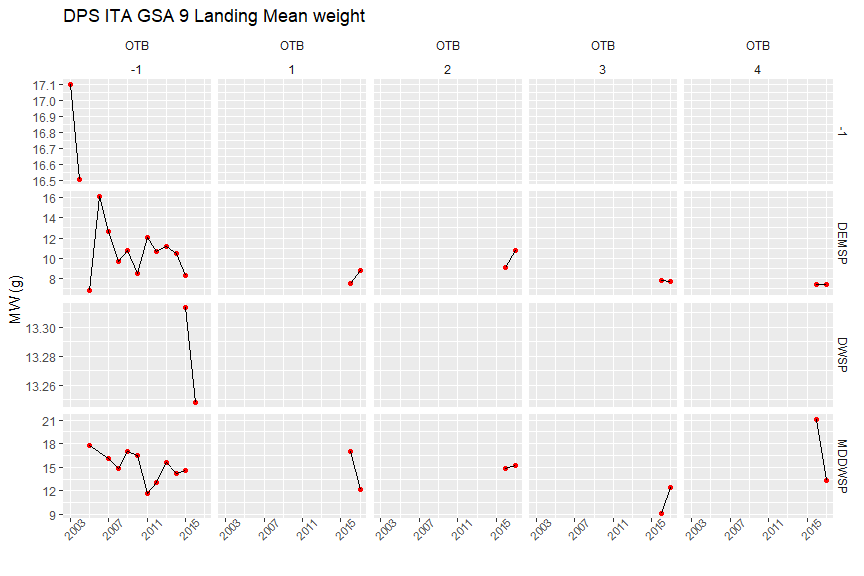

```r
MEDBS_land_mean_weight(data=Landing_tab_example,SP="DPS",MS="ITA",GSA="GSA 9")[[2]]
```

### Plot of total landing by gear and fishery

The function `MEDBS_plot_land_vol` allows to visual check the time series of landing volumes by fishery of a selected species. The function returns a plot of the total landing time series by fishery and gear.

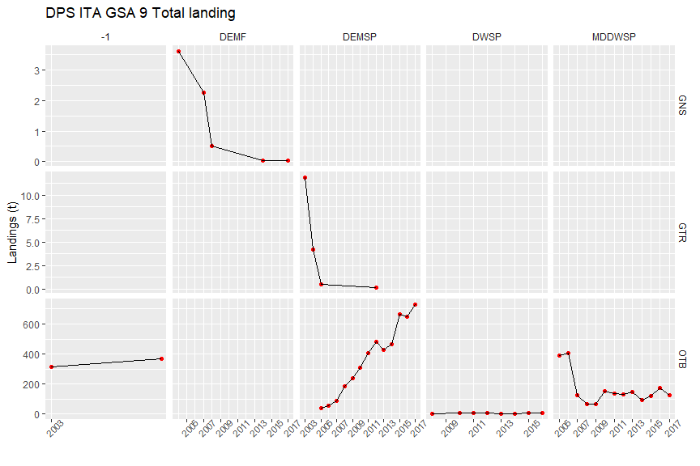

```r
MEDBS_plot_land_vol(data=Landing_tab_example,SP="DPS",MS="ITA",GSA="GSA 9")
```

### Plot of total landing

The function `MEDBS_plot_landing_ts` estimates the total landings time series by both year and quarters for a selected combination of member state, GSA and species. The function returns a plot of the total landing time series by year or by quarters. The plot by year also reports the landing by gear.

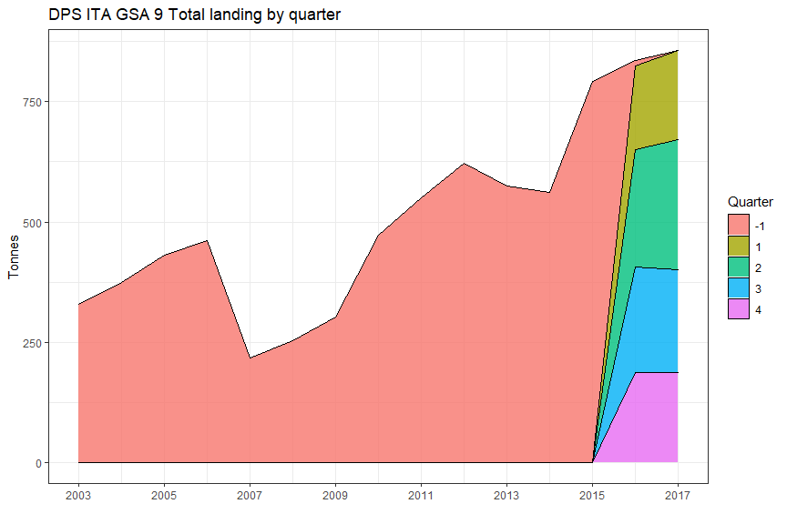

```r
suppressMessages(MEDBS_plot_landing_ts(data=Landing_tab_example,SP="DPS",MS="ITA",GSA="GSA 9",by="quarter"))
```

### check the coverage in Landing table

The function `MEDBS_Landing_coverage` allows to check the coverage in landing table providing a summary table

```r
results <- suppressMessages(MEDBS_Landing_coverage(Landing_tab_example,"DPS","ITA","GSA 9"))
head(results[[1]])
```

```
#>   COUNTRY YEAR QUARTER VESSEL_LENGTH GEAR MESH_SIZE_RANGE FISHERY  AREA SPECIES
#> 1     ITA 2003      -1            -1  OTB          50D100      -1 GSA 9     DPS
#> 2     ITA 2004      -1            -1  OTB          50D100      -1 GSA 9     DPS
#> 3     ITA 2004      -1            -1  GNS              -1    DEMF GSA 9     DPS
#> 4     ITA 2007      -1            -1  GNS              -1    DEMF GSA 9     DPS
#> 5     ITA 2008      -1            -1  GNS              -1    DEMF GSA 9     DPS
#> 6     ITA 2014      -1            -1  GNS              -1    DEMF GSA 9     DPS
#>    LANDINGS
#> 1 316.61597
#> 2 367.43191
#> 3   3.62883
#> 4   2.26308
#> 5   0.50829
#> 6   0.02736
```

a plot of the landing coverage is also provided.

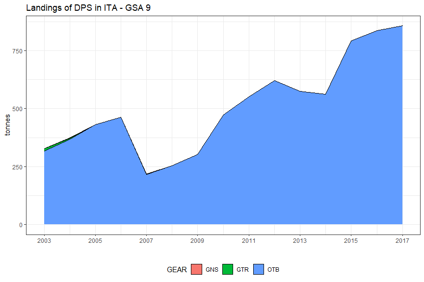

```r
results[[2]]
```

## Checks on discards

### check the coverage in discard table

The function `MEDBS_discard_coverage` allows to check the coverage of the time series in discard table for a selected species. The function returns a summary table.

```r
results <- suppressMessages(MEDBS_discard_coverage(Discard_tab_example,"DPS","ITA","GSA 9"))
head(results[[1]])
```

```
#>   country year quarter vessel_length gear mesh_size_range fishery  area species
#> 1     ITA 2009      -1            -1  OTB          50D100   DEMSP GSA 9     DPS
#> 2     ITA 2010      -1            -1  OTB          50D100   DEMSP GSA 9     DPS
#> 3     ITA 2011      -1            -1  OTB          50D100   DEMSP GSA 9     DPS
#> 4     ITA 2012      -1            -1  OTB          50D100   DEMSP GSA 9     DPS
#> 5     ITA 2013      -1            -1  OTB          50D100   DEMSP GSA 9     DPS
#> 6     ITA 2014      -1            -1  OTB          50D100   DEMSP GSA 9     DPS
#>    discards
#> 1 76.710840
#> 2 24.396528
#> 3 60.519315
#> 4  6.571266
#> 5 26.761695
#> 6 44.978926
```

A plots of discard time series by year and gear is also provided.

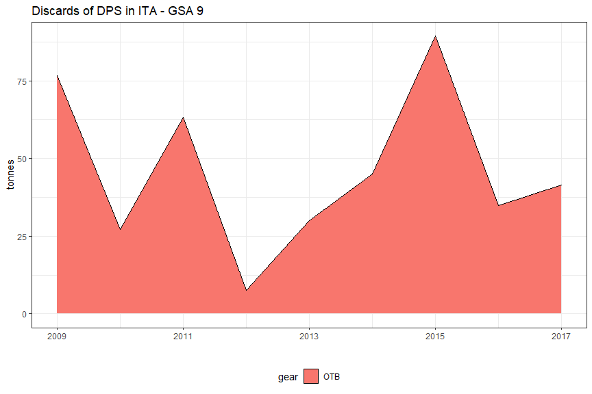

```r
results[[2]]
```

### Comparison between discards in weight by quarter and -1

The function `MEDBS_comp_disc_YQ` allows to compare the discards weights aggregated by quarter and by year for a selected species at the gear level. The function returns a data frame for the comparison of discards aggregated by quarters and by year

```r
MEDBS_comp_disc_YQ(data=Discard_tab_example,SP="DPS",MS="ITA",GSA="GSA 9")
```

```
#>   YEAR GEAR    tot_q    tot_yr ratio
#> 1 2009  OTB       NA 76.710840    NA
#> 2 2010  OTB       NA 27.100131    NA
#> 3 2011  OTB       NA 63.262841    NA
#> 4 2012  OTB       NA  7.568045    NA
#> 5 2013  OTB       NA 30.040906    NA
#> 6 2014  OTB       NA 44.978926    NA
#> 7 2015  OTB       NA 89.320018    NA
#> 8 2016  OTB 34.93873        NA    NA
#> 9 2017  OTB 41.46659        NA    NA
```

### Comparison between discards in weight by quarter, quarter -1 and by fishery

The function `MEDBS_comp_disc_YQ_fishery` allow to estimates the discards in weight for a selected species by quarter and fishery. The function returns a data frame for the comparison of discards aggregated by quarters and by year and fishery

```r
results <- MEDBS_comp_disc_YQ_fishery(data=Discard_tab_example,MS="ITA",GSA="GSA 9",SP="DPS")
head(results)
```

```
#>   YEAR GEAR FISHERY tot_q    tot_yr ratio
#> 1 2009  OTB   DEMSP    NA 76.710840    NA
#> 2 2010  OTB   DEMSP    NA 24.396528    NA
#> 3 2010  OTB  MDDWSP    NA  2.703603    NA
#> 4 2011  OTB   DEMSP    NA 60.519315    NA
#> 5 2011  OTB  MDDWSP    NA  2.743526    NA
#> 6 2012  OTB   DEMSP    NA  6.571266    NA
```

### Check mean weight by year,gear and fishery aggregation in discard

The function `MEDBS_disc_mean_weight` allows to check consistency of mean discard weight of a selected species providing a table of the mean individual weight by year, gear and fishery.

```r
results <- MEDBS_disc_mean_weight(data=Discard_tab_example,SP="DPS",MS="ITA",GSA="GSA 9")
head(results[[1]])
```

```
#>   YEAR QUARTER VESSEL_LENGTH GEAR MESH_SIZE_RANGE FISHERY     totW       totN
#> 1 2009      -1            -1  OTB          50D100   DEMSP 76710840 22633620.8
#> 2 2010      -1            -1  OTB          50D100   DEMSP 24396528  6011330.6
#> 3 2010      -1            -1  OTB          50D100  MDDWSP  2703603   345221.9
#> 4 2011      -1            -1  OTB          50D100   DEMSP 60519315 29133415.7
#> 5 2011      -1            -1  OTB          50D100  MDDWSP  2743526   744126.7
#> 6 2012      -1            -1  OTB          50D100   DEMSP  6571266   998156.0
#>         MW
#> 1 3.389243
#> 2 4.058424
#> 3 7.831493
#> 4 2.077316
#> 5 3.686907
#> 6 6.583406
```

The function also returns a plot of the mean discards weight by year, gear and fishery aggregation.

```r
results[[2]]
```

```
#> geom_path: Each group consists of only one observation. Do you need to adjust
#> the group aesthetic?
#> geom_path: Each group consists of only one observation. Do you need to adjust
#> the group aesthetic?
```

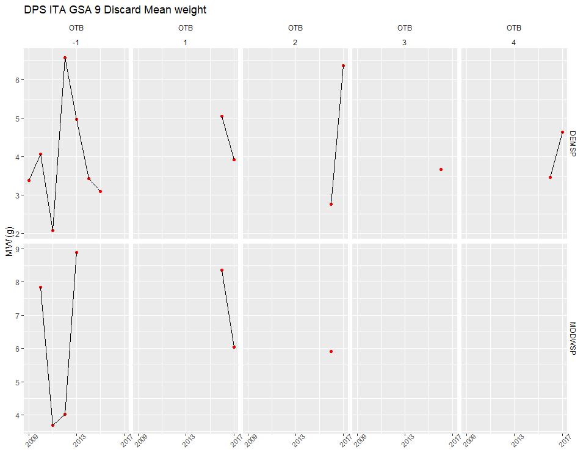

### Plot of total discards by gear and fishery

The function `MEDBS_plot_disc_vol` allows to visual check the time series of discard volumes by fishery of a selected species. The function returns a plot of the total discards time series by fishery and gear.

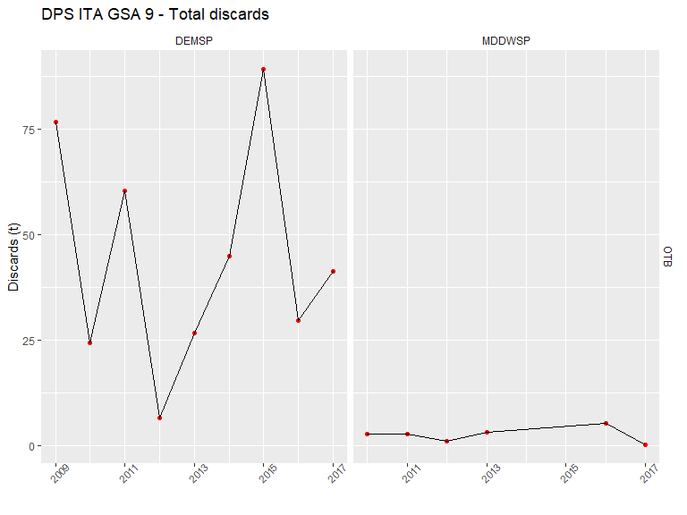

```r
MEDBS_plot_disc_vol(data=Discard_tab_example,SP="DPS",MS="ITA",GSA="GSA 9")
```

### Plot of total discards time series

The function `MEDBS_plot_discard_ts` estimates the total discard time series by both year and quarters for a selected combination of member state, GSA and species. The function returns a plot of the total discard time series by year or by quarters. The parameter `by="year"` also reports the landing by gear.

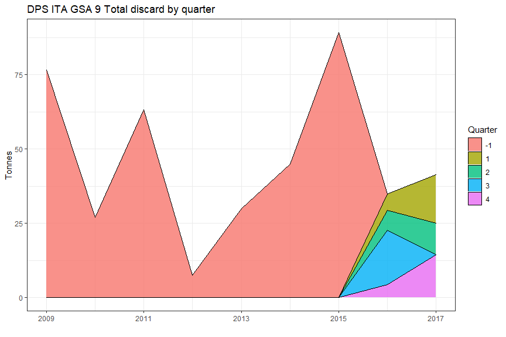

```r
MEDBS_plot_discard_ts(data=Discard_tab_example,SP="DPS",MS="ITA",GSA="GSA 9",by="quarter")
```

## Other checks

### GP_tab (growth params) table check

```r
results <- MEDBS_GP_check(GP_tab_example,"MUT","ITA","18")
results[[1]]
```

[output not shown]

```r
print(names(results)[1])
```

[output not shown]

```r
print(names(results)[2])
```

[output not shown]

```r
results[[2]]
```

[output not shown]

```r
print(names(results)[3])
```

[output not shown]

```r
results[[3]]
```

[output not shown]

```r
print(names(results)[4])
```

[output not shown]

```r
results[[4]]
```

[output not shown]

```r
print(names(results)[5])
```

[output not shown]

```r
results[[5]]
```

[output not shown]

```r
print(names(results)[6])
```

[output not shown]

```r
results[[6]]
```

[output not shown]

```r
print(names(results)[7])
```

[output not shown]

```r
results[[7]]
```

[output not shown]

```r
print(names(results)[8])
```

[output not shown]

```r
results[[8]]
```

[output not shown]

### LW params in GP_tab in table check

The function `MEDBS_LW_check` allows to check the length-weight parameters included in the GP table for a selected species. The function returns a summary table.

```r
results <- MEDBS_LW_check(GP_tab_example,"MUT","ITA","GSA 18")
results[[1]]
```

```
#>    COUNTRY   AREA START_YEAR END_YEAR SPECIES SEX NA
#> 1      ITA GSA 18       2014     2014     MUT   C  1
#> 2      ITA GSA 18       2015     2015     MUT   C  1
#> 3      ITA GSA 18       2016     2016     MUT   C  1
#> 4      ITA GSA 18       2017     2017     MUT   C  1
#> 5      ITA GSA 18       2014     2014     MUT   F  1
#> 6      ITA GSA 18       2015     2015     MUT   F  1
#> 7      ITA GSA 18       2016     2016     MUT   F  1
#> 8      ITA GSA 18       2017     2017     MUT   F  1
#> 9      ITA GSA 18       2014     2014     MUT   M  1
#> 10     ITA GSA 18       2015     2015     MUT   M  1
#> 11     ITA GSA 18       2016     2016     MUT   M  1
#> 12     ITA GSA 18       2017     2017     MUT   M  1
```

plots of the length-weigth relationships for the selected species by year and sex are also returned.

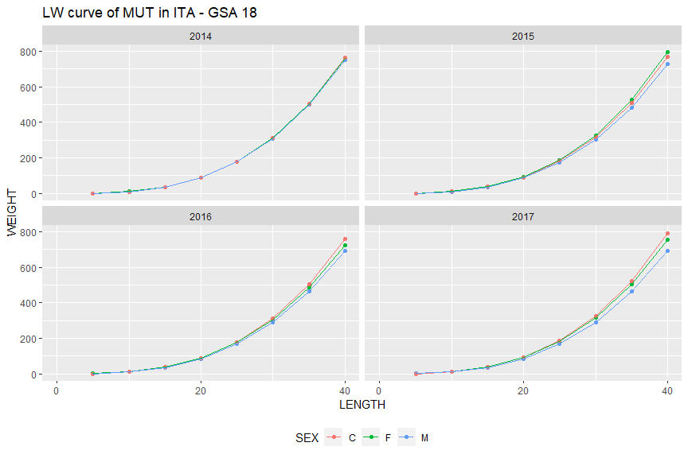

```r
results[[2]]
```

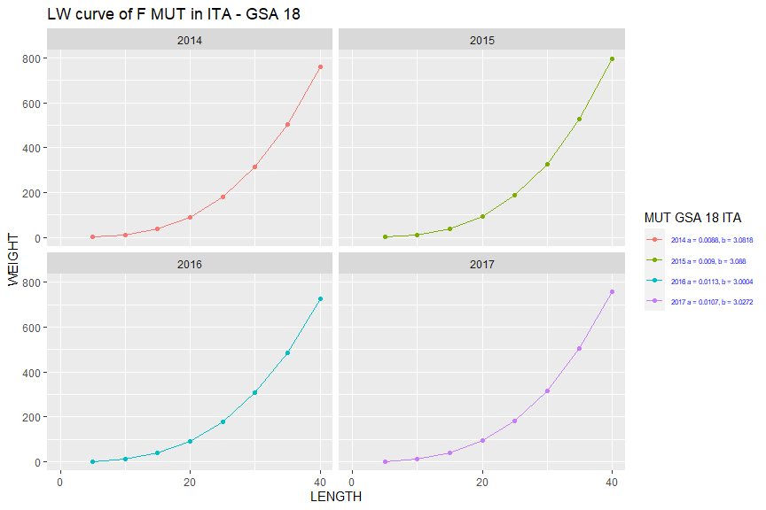

```r
results[[3]]
```

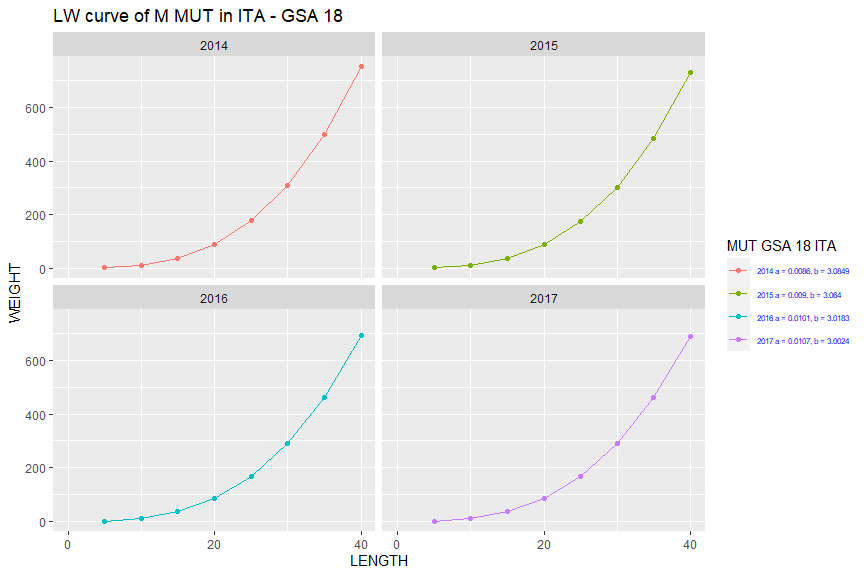

```r
results[[4]]
```

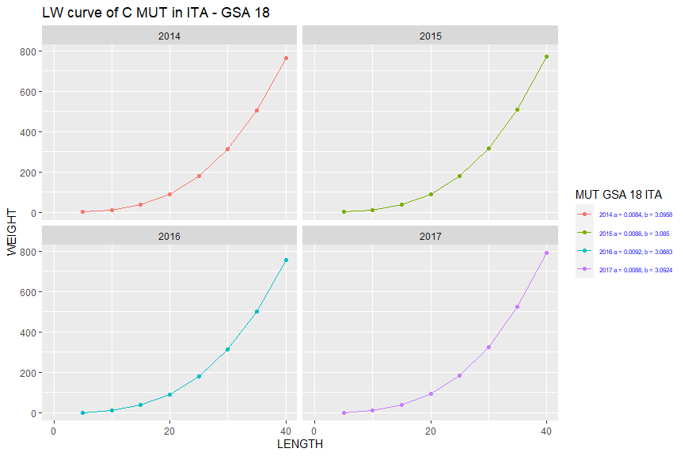

```r
results[[5]]
```

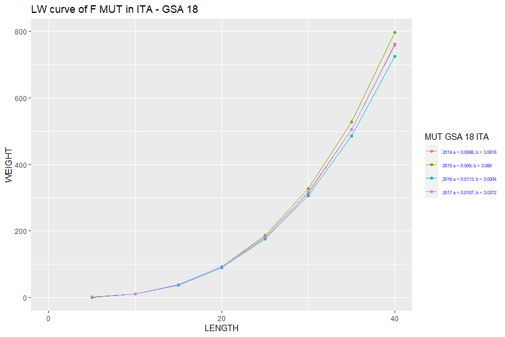

```r
results[[6]]
```

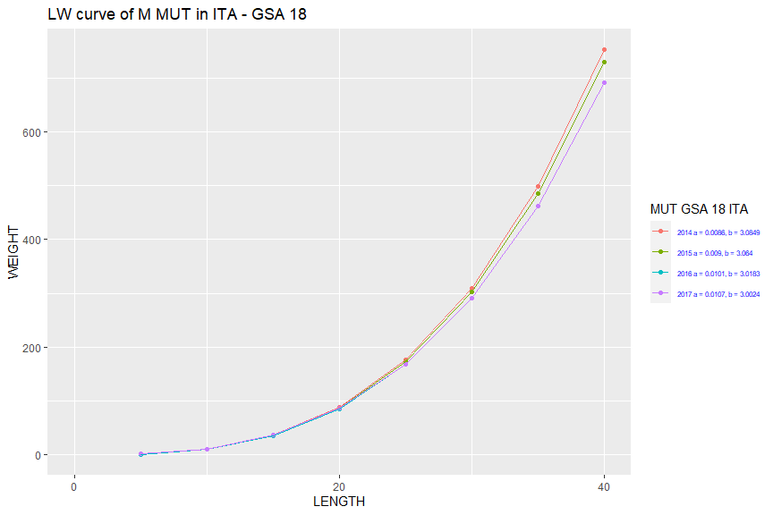

```r
results[[7]]
```

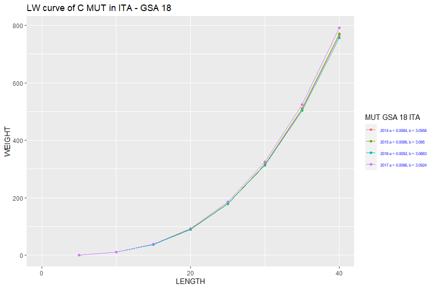

```r
results[[8]]
```

### MA_tab (maturity at age) table check

The function `MEDBS_MA_check` allows to check the maturity at age (MA) table providing a summary table of the data coverage.

```r
results <- MEDBS_MA_check(MA_tab_example,"DPS","ITA","GSA 99")
results[[1]]
```

[output not shown]

The function also provides plots for the selected species of the proportion of matures for age class by sex and year.

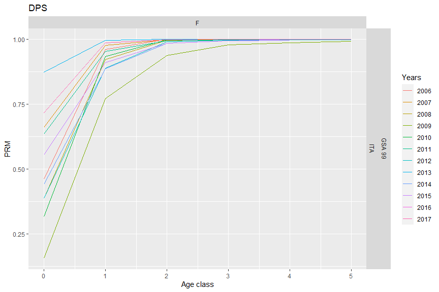

```r
results[[2]]
```

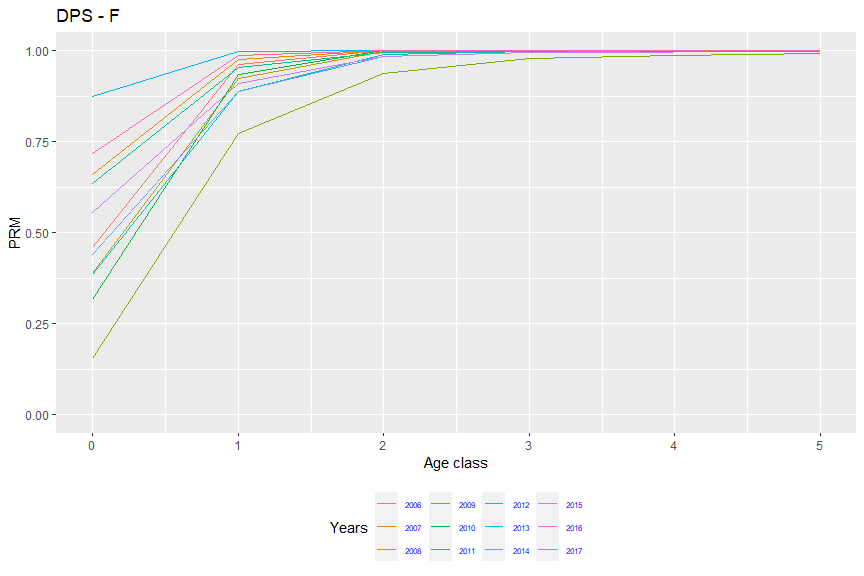

```r
results[[3]]
```

### ML_tab (maturity at length) table check

```r
results <- MEDBS_ML_check(ML_tab_example, "DPS", "ITA", "GSA 99")
```

[figure not shown]

[figure not shown]

```r
results[[1]]
```

```
#>    COUNTRY   YEAR START_YEAR END_YEAR SPECIES SEX
#> 1      ITA GSA 99       2006     2006     DPS   F
#> 2      ITA GSA 99       2007     2007     DPS   F
#> 3      ITA GSA 99       2008     2008     DPS   F
#> 4      ITA GSA 99       2009     2009     DPS   F
#> 5      ITA GSA 99       2010     2010     DPS   F
#> 6      ITA GSA 99       2011     2011     DPS   F
#> 7      ITA GSA 99       2012     2012     DPS   F
#> 8      ITA GSA 99       2013     2013     DPS   F
#> 9      ITA GSA 99       2014     2014     DPS   F
#> 10     ITA GSA 99       2015     2015     DPS   F
#> 11     ITA GSA 99       2016     2016     DPS   F
#> 12     ITA GSA 99       2017     2017     DPS   F
```

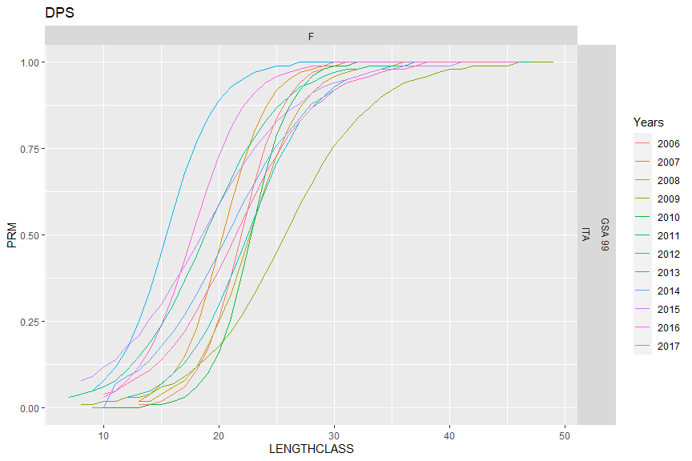

```r
results[[2]]
```

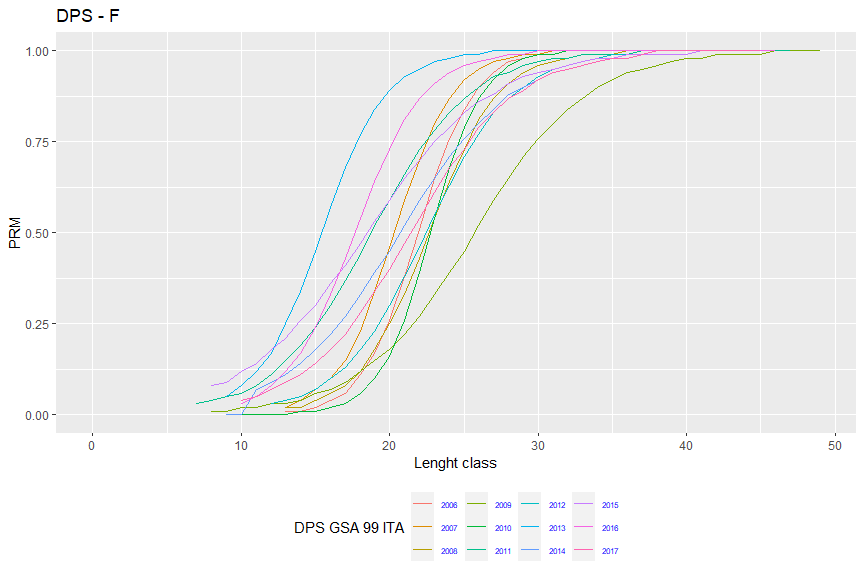

```r
results[[3]]
```

### SA_tab (sex ratio at age) table check

The function `MEDBS_SA_check` allows to check the sex ratio at age (SA) table providing a summary table of the data coverage for the selected species of the proportion of sex ratio for age class by year.

```r
results <- MEDBS_SA_check(SA_tab_example, "DPS", "ITA", "GSA 99")
results[[1]]
```

```
#>    COUNTRY   YEAR START_YEAR END_YEAR SPECIES
#> 1      ITA GSA 99       2003     2005     DPS
#> 2      ITA GSA 99       2006     2006     DPS
#> 3      ITA GSA 99       2007     2007     DPS
#> 4      ITA GSA 99       2008     2008     DPS
#> 5      ITA GSA 99       2009     2009     DPS
#> 6      ITA GSA 99       2010     2010     DPS
#> 7      ITA GSA 99       2011     2011     DPS
#> 8      ITA GSA 99       2012     2012     DPS
#> 9      ITA GSA 99       2013     2013     DPS
#> 10     ITA GSA 99       2014     2014     DPS
#> 11     ITA GSA 99       2015     2015     DPS
#> 12     ITA GSA 99       2016     2016     DPS
#> 13     ITA GSA 99       2017     2017     DPS
```

Plots for the selected species of the proportion of sex ratio for age class by year are also returned.

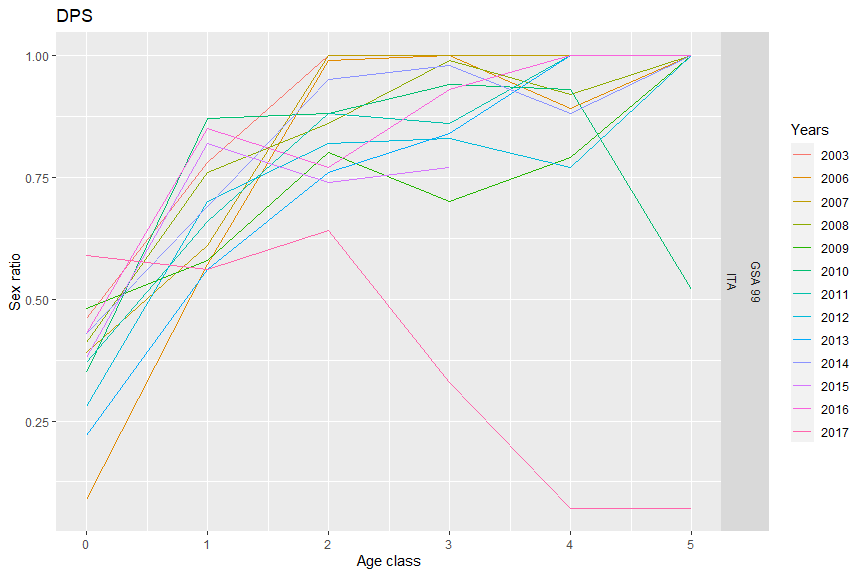

```r
results[[2]]
```

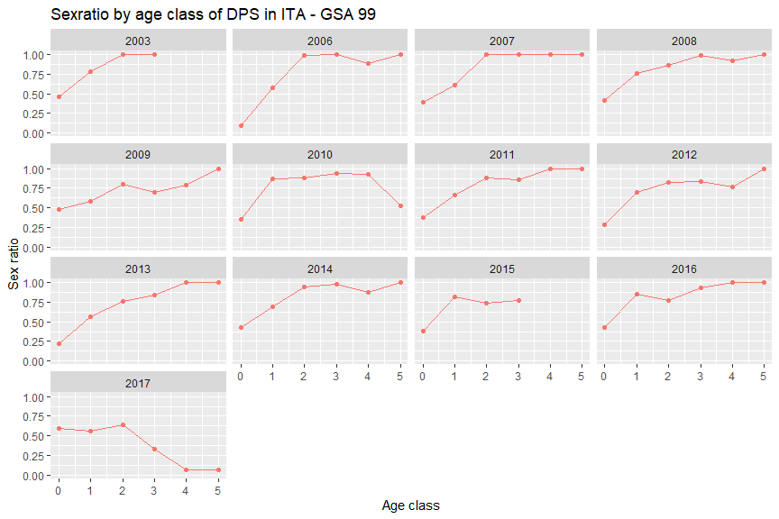

```r
results[[3]]
```

### SL_tab (sex ratio at length) table check

The function `MEDBS_SL_check` allows to check the sex ratio at length (SL) table providing a summary table of the data coverage for the selected species of the proportion of sex ratio for length class by year.

```r
results <- MEDBS_SL_check(SL_tab_example,"DPS","ITA","GSA 99")
results[[1]]
```

```
#>    COUNTRY   YEAR START_YEAR END_YEAR SPECIES
#> 1      ITA GSA 99       2003     2005     DPS
#> 2      ITA GSA 99       2006     2006     DPS
#> 3      ITA GSA 99       2007     2007     DPS
#> 4      ITA GSA 99       2008     2008     DPS
#> 5      ITA GSA 99       2009     2009     DPS
#> 6      ITA GSA 99       2010     2010     DPS
#> 7      ITA GSA 99       2011     2011     DPS
#> 8      ITA GSA 99       2012     2012     DPS
#> 9      ITA GSA 99       2013     2013     DPS
#> 10     ITA GSA 99       2014     2014     DPS
#> 11     ITA GSA 99       2015     2015     DPS
#> 12     ITA GSA 99       2016     2016     DPS
#> 13     ITA GSA 99       2017     2017     DPS
```

Plots for the selected species of the proportion of sex ratio for length class by year are returned.

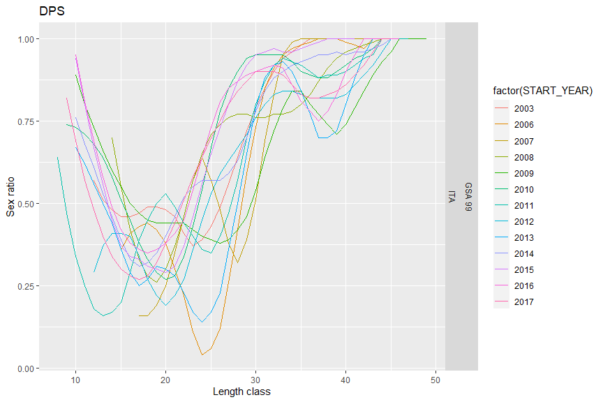

```r
results[[2]]
```

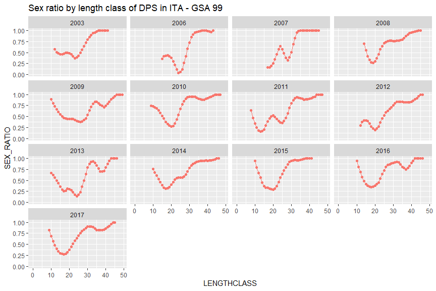

```r
results[[3]]
```

# Checks on FDI tables

## Table G

### Check empty fields in FDI G table

The function `check_EF_FDI_G` checks the presence of not allowed empty data in the given table, according to the ‘Fisheries Dependent Information data call 2021 - Annex 1’. A list is returned by the function. The first list’s object is a vector containing the number of NA for each reference column.

```r
check_EF_FDI_G(fdi_g_effort, verbose=FALSE)[[1]]
```

```
#>           country              year           quarter     vessel_length
#>                 0                 0                 0                 0
#>      fishing_tech         gear_type target_assemblage   mesh_size_range
#>                 0                 0                 0                 0
#>            metier      supra_region        sub_region     eez_indicator
#>                 0                 0                 0                 0
#>     geo_indicator       specon_tech              deep        totseadays
#>                 0                 0                 0                 0
#>    totkwdaysatsea    totgtdaysatsea       totfishdays     totkwfishdays
#>                 0                 0                 0                 0
#>     totgtfishdays             hrsea           kwhrsea           gthrsea
#>                 0                 0                 0                 0
#>            totves      confidential
#>                 0                 0
```

The second list’s object gives the index of each NA in the reference column.

```r
check_EF_FDI_G(fdi_g_effort, verbose=FALSE)[[2]]
```

```
#> $country
#> integer(0)
#>
#> $year
#> integer(0)
#>
#> $quarter
#> integer(0)
#>
#> $vessel_length
#> integer(0)
#>
#> $fishing_tech
#> integer(0)
#>
#> $gear_type
#> integer(0)
#>
#> $target_assemblage
#> integer(0)
#>
#> $mesh_size_range
#> integer(0)
#>
#> $metier
#> integer(0)
#>
#> $supra_region
#> integer(0)
#>
#> $sub_region
#> integer(0)
#>
#> $eez_indicator
#> integer(0)
#>
#> $geo_indicator
#> integer(0)
#>
#> $specon_tech
```

[output cut: 22 more lines]

```
#>
#> $hrsea
#> integer(0)
#>
#> $kwhrsea
#> integer(0)
#>
#> $gthrsea
#> integer(0)
#>
#> $totves
#> integer(0)
#>
#> $confidential
#> integer(0)
```

### Check duplicated records in FDI G table

The function `check_RD_FDI_G` check the presence of duplicated records. In particular, it checks whether the combination of the first 15 columns generates duplicate records. The function returns the indices of the duplicated rows.

```r
g_effort <- rbind(fdi_g_effort,fdi_g_effort[1,])
check_RD_FDI_G(g_effort)
```

```
#> 1 record/s duplicated
#> [1] 6
```

## Table H

### Check empty fields in FDI H table

The function `check_EF_FDI_H` checks the presence of not allowed empty data in the given table, according to the ‘Fisheries Dependent Information data call 2021 - Annex 1’. A list is returned by the function. The first list’s object is a vector containing the number of NA for each reference column.

```r
check_EF_FDI_H(fdi_h_spatial_land, verbose=FALSE)[[1]]
```

```
#>           country              year           quarter     vessel_length
#>                 0                 0                 0                 0
#>      fishing_tech         gear_type target_assemblage   mesh_size_range
#>                 0                 0                 0                 0
#>            metier      supra_region        sub_region     eez_indicator
#>                 0                 0                 0                 0
#>     geo_indicator       specon_tech              deep    rectangle_type
#>                 0                 0                 0                 0
#>     rectangle_lat     rectangle_lon          c_square           species
#>                 0                 0                 0                 0
#>      totwghtlandg       totvallandg      confidential
#>                 0                 0                 0
```

The second list’s object gives the index of each NA in the reference column.

```r
check_EF_FDI_H(fdi_h_spatial_land, verbose=FALSE)[[2]]
```

```
#> $country
#> integer(0)
#>
#> $year
#> integer(0)
#>
#> $quarter
#> integer(0)
#>
#> $vessel_length
#> integer(0)
#>
#> $fishing_tech
#> integer(0)
#>
#> $gear_type
#> integer(0)
#>
#> $target_assemblage
#> integer(0)
#>
#> $mesh_size_range
#> integer(0)
#>
#> $metier
#> integer(0)
#>
#> $supra_region
#> integer(0)
#>
#> $sub_region
#> integer(0)
#>
#> $eez_indicator
#> integer(0)
#>
#> $geo_indicator
#> integer(0)
#>
#> $specon_tech
```

[output cut: 13 more lines]

```
#>
#> $c_square
#> integer(0)
#>
#> $species
#> integer(0)
#>
#> $totwghtlandg
#> integer(0)
#>
#> $totvallandg
#> integer(0)
#>
#> $confidential
#> integer(0)
```

### Check duplicated records in FDI H table

The function `check_RD_FDI_H` check the presence of duplicated records. In particular, it checks whether the combination of the first 15 columns generates duplicate records. The function returns the indices of the duplicated rows.

```r
h_spatial_land <- rbind(fdi_h_spatial_land,fdi_h_spatial_land[1,])
check_RD_FDI_H(h_spatial_land)
```

```
#> 1 record/s duplicated
#> [1] 6
```

## Table I

### Check empty fields in FDI I table

The function `check_EF_FDI_I` checks the presence of not allowed empty data in the given table, according to the ‘Fisheries Dependent Information data call 2021 - Annex 1’. A list is returned by the function. The first list’s object is a vector containing the number of NA for each reference column.

```r
check_EF_FDI_I(fdi_i_spatial_fe,verbose=FALSE)[[1]]
```

```
#>           country              year           quarter     vessel_length
#>                 0                 0                 0                 0
#>      fishing_tech         gear_type target_assemblage   mesh_size_range
#>                 0                 0                 0                 0
#>            metier      supra_region        sub_region     eez_indicator
#>                 0                 0                 0                 0
#>     geo_indicator       specon_tech              deep    rectangle_type
#>                 0                 0                 0                 0
#>     rectangle_lat     rectangle_lon          c_square       totfishdays
#>                 0                 0                 0                 0
#>      confidential
#>                 0
```

The second list’s object gives the index of each NA in the reference column.

```r
check_EF_FDI_I(fdi_i_spatial_fe,verbose=FALSE)[[2]]
```

```
#> $country
#> integer(0)
#>
#> $year
#> integer(0)
#>
#> $quarter
#> integer(0)
#>
#> $vessel_length
#> integer(0)
#>
#> $fishing_tech
#> integer(0)
#>
#> $gear_type
#> integer(0)
#>
#> $target_assemblage
#> integer(0)
#>
#> $mesh_size_range
#> integer(0)
#>
#> $metier
#> integer(0)
#>
#> $supra_region
#> integer(0)
#>
#> $sub_region
#> integer(0)
#>
#> $eez_indicator
#> integer(0)
#>
#> $geo_indicator
#> integer(0)
#>
#> $specon_tech
#> integer(0)
#>
#> $deep
#> integer(0)
#>
#> $rectangle_type
#> integer(0)
#>
#> $rectangle_lat
#> integer(0)
#>
#> $rectangle_lon
#> integer(0)
#>
#> $c_square
#> integer(0)
#>
#> $totfishdays
#> integer(0)
#>
#> $confidential
#> integer(0)
```

### Check duplicated records in FDI I table

The function `check_RD_FDI_I` check the presence of duplicated records. In particular, it checks whether the combination of the first 15 columns generates duplicate records. The function returns the indices of the duplicated rows.

```r
i_spatial_fe <- rbind(fdi_i_spatial_fe,fdi_i_spatial_fe[1,])
check_RD_FDI_I(i_spatial_fe)
```

```
#> 1 record/s duplicated
#> [1] 6
```

## Table J

### Check empty fields in FDI J table

The function `check_EF_FDI_J` checks the presence of not allowed empty data in the given table, according to the Fisheries Dependent Information data call 2021 - Annex 1. A list is returned by the function. The first list’s object is a vector containing the number of NA for each reference column.

```r
check_EF_FDI_J(fdi_j_capacity, verbose=FALSE)[[1]]
```

```
#>              country                 year        vessel_length
#>                    0                    0                    0
#>         fishing_tech         supra_region        geo_indicator
#>                    0                    0                    0
#> principal_sub_region             tottrips                totkw
#>                    0                    0                    0
#>                totgt               totves               avgage
#>                    0                    0                    0
#>               avgloa           maxseadays
#>                    0                    0
```

The second list’s object gives the index of each NA in the reference column.

```r
check_EF_FDI_J(fdi_j_capacity, verbose=FALSE)[[2]]
```

```
#> $country
#> integer(0)
#>
#> $year
#> integer(0)
#>
#> $vessel_length
#> integer(0)
#>
#> $fishing_tech
#> integer(0)
#>
#> $supra_region
#> integer(0)
#>
#> $geo_indicator
#> integer(0)
#>
#> $principal_sub_region
#> integer(0)
#>
#> $tottrips
#> integer(0)
#>
#> $totkw
#> integer(0)
#>
#> $totgt
#> integer(0)
#>
#> $totves
#> integer(0)
#>
#> $avgage
#> integer(0)
#>
#> $avgloa
#> integer(0)
#>
#> $maxseadays
#> integer(0)
```

### Check duplicated records in FDI J table

```r
j_capacity <- rbind(fdi_j_capacity,fdi_j_capacity[1,])
check_RD_FDI_J(j_capacity)
```

```
#> 1 record/s duplicated
#> [1] 6
```

# GFCM data format

## Task II.2 table

### Check empty fields in GFCM Task II.2 table

The function `check_EF_taskII2` checks the presence of not allowed empty data in the given table, according to the GFCM Data Collection Reference Framework (DCRF, V. 20.1). The function returns two lists. The first list gives the number of NA for each reference column.

```r
check_EF_taskII2(task_ii2, verbose=FALSE)[[1]]
```

```
#> Reference_Year            CPC            GSA        Segment        Species
#>              0              0              0              0              0
#>        Landing          Catch
#>              0              0
```

The second list returns the index of each NA in the reference column.

```r
check_EF_taskII2(task_ii2, verbose=FALSE)[[2]]
```

```
#> $Reference_Year
#> integer(0)
#>
#> $CPC
#> integer(0)
#>
#> $GSA
#> integer(0)
#>
#> $Segment
#> integer(0)
#>
#> $Species
#> integer(0)
#>
#> $Landing
#> integer(0)
#>
#> $Catch
#> integer(0)
```

### Check of missing combination GSA/Fleet segment per year

Function `check_presence_taskII2` allows to verify the completeness of the GSA/Fleet segments in Task II.2 table, as reported in the combination_taskII2 table. The output is a list of missing combinations GSA/Fleet segment per year.

```r
check_presence_taskII2(task_ii2,combination_taskII2,MS="ITA",GSA="18")
```

```
#> No reference values for the following years: 2017.
```

### Check duplicated records in GFCM Task II.2 table

The function `check_RD_taskII2` checks the presence of duplicated records. In particular, it checks whether the combination of the first 5 columns generates duplicate records. The function returns the indices of the duplicated rows, checking the unique combinations of the first 5 columns of the Task II.2 table.

```r
ii2 <- rbind(task_ii2,task_ii2[1,])
check_RD_taskII2(ii2)
```

```
#> 1 record/s duplicated
#> [1] 6
```

## Task III table

### Check empty fields in GFCM Task III table

The function `check_EF_taskIII` checks the presence of not allowed empty data in the given table, according to the GFCM Data Collection Reference Framework (DCRF, V. 20.1). The function returns two lists. The first list gives the number of NA for each reference column.

```r
check_EF_taskIII(task_iii,verbose=FALSE)[[1]]
```

```
#> Reference_Year            CPC            GSA        Segment          Group
#>              0              0              0              0              0
#>           Date         Source   NumberCaught
#>              0              0              0
```

The second list returns the index of each NA in the reference column.

```r
check_EF_taskIII(task_iii,verbose=FALSE)[[2]]
```

```
#> $Reference_Year
#> integer(0)
#>
#> $CPC
#> integer(0)
#>
#> $GSA
#> integer(0)
#>
#> $Segment
#> integer(0)
#>
#> $Group
#> integer(0)
#>
#> $Date
#> integer(0)
#>
#> $Source
#> integer(0)
#>
#> $NumberCaught
#> integer(0)
```

### Check duplicated records in GFCM Task III table

```r
check_RD_taskIII(task_iii)
```

```
#> no duplicated lines in the data frame
#> integer(0)
```

## Task VII.2 table

### Check empty fields in GFCM Task VII.2 table

The function `check_EF_taskVII2` checks the presence of not allowed empty data in the given table, according to the GFCM Data Collection Reference Framework (DCRF, V. 20.1). The function returns two lists. The first list gives the number of NA for each reference column.

```r
check_EF_taskVII2(task_vii2, verbose=FALSE)[[1]]
```

```
#>            Reference_Year                       CPC                       GSA
#>                         0                         0                         0
#>                    Source                SurveyName                   Segment
#>                         0                         0                         0
#>                   Species                LengthUnit                    Length
#>                         0                         0                         0
#> NumberIndividualsMeasured  WeightIndividualsSampled NumberIndividualsExpanded
#>                         0                         0                         0
```

The second list returns the index of each NA in the reference column.

```r
check_EF_taskVII2(task_vii2, verbose=FALSE)[[2]]
```

```
#> $Reference_Year
#> integer(0)
#>
#> $CPC
#> integer(0)
#>
#> $GSA
#> integer(0)
#>
#> $Source
#> integer(0)
#>
#> $SurveyName
#> integer(0)
#>
#> $Segment
#> integer(0)
#>
#> $Species
#> integer(0)
#>
#> $LengthUnit
#> integer(0)
#>
#> $Length
#> integer(0)
#>
#> $NumberIndividualsMeasured
#> integer(0)
#>
#> $WeightIndividualsSampled
#> integer(0)
#>
#> $NumberIndividualsExpanded
#> integer(0)
```

### Check duplicated records in GFCM Task VII.2 table

The function `check_RD_taskVII2` checks the presence of duplicated records. In particular, it checks whether the combination of the first 9 columns generates duplicate records. The function returns the indices of the duplicated rows, checking the unique combinations of the first 9 columns of the Task VII.2 table.

```r
check_RD_taskVII2(task_vii2)
```

```
#> no duplicated lines in the data frame
#> integer(0)
```

### Comparison between min/max lengths observed for each species with theoretical values

The function `check_minmaxl_TaskVII.2` allows to verify the consistency of the lengths reported in the TaskVII.2 table with the theoretical values reported in the minmaxLtaskVII2 table. The function allows to identify the records in which the observed lengths are greater or lower than the expected ones.

```r
check_minmaxl_TaskVII.2(task_vii2,minmaxLtaskVII2,MS="ITA",GSA="18")
```

```
#>   Species min_observed max_observed min_theoretical max_theoretical check_min
#> 1     BOG          8.5           18               5             100
#>   check_max
#> 1
```

### Plot of the relationship length weight for each species

The function `check_lw_TaskVII.2` allows to check the consistency of length-weight relationship in the GFCM Task VII.2 table by species. The function returns a plot of the length weight relationship per species.

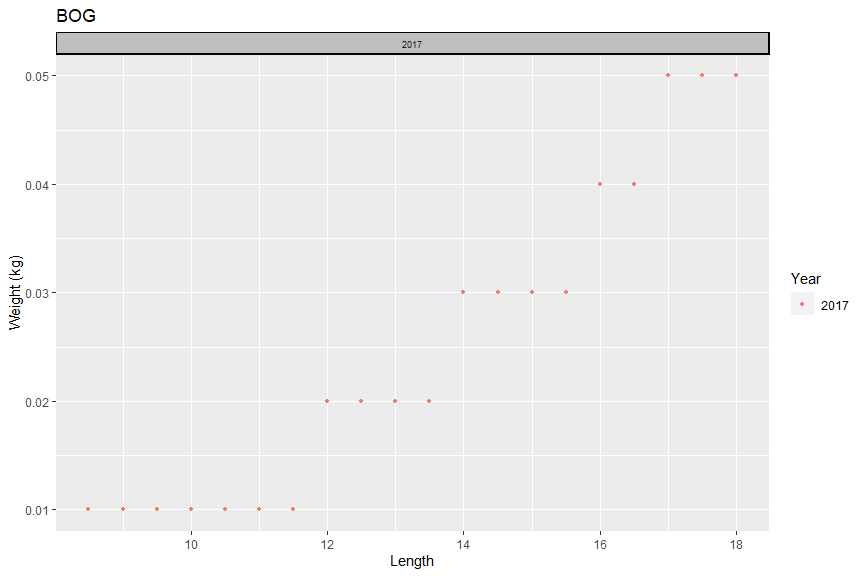

```r
check_lw_TaskVII.2(task_vii2, MS = "ITA", GSA = "18", SP = "BOG")
```

## Task VII.3.1 table

### Check empty fields in GFCM Task VII.3.1 table

The function `check_EF_TaskVII31` checks the presence of not allowed empty data in the given table, according to the GFCM Data Collection Reference Framework (DCRF, V. 20.1). The function returns two lists. The first list gives the number of NA for each reference column.

```r
check_EF_TaskVII31(task_vii31, verbose=FALSE)[[1]]
```

```
#> Reference_Year            CPC            GSA        Species            Sex
#>              0              0              0              0              0
#>            L50
#>              0
```

The second list returns the index of each NA in the reference column.

```r
check_EF_TaskVII31(task_vii31, verbose=FALSE)[[2]]
```

```
#> $Reference_Year
#> integer(0)
#>
#> $CPC
#> integer(0)
#>
#> $GSA
#> integer(0)
#>
#> $Species
#> integer(0)
#>
#> $Sex
#> integer(0)
#>
#> $L50
#> integer(0)
```

### Comparison between min/max L50 observed for each species and sex with theoretical values

The function `check_minmaxl50_TaskVII.3.1` allows to verify the consistency of L50 reported in the TaskVII.3.1 table with the theoretical values reported in the minmaxLtaskVII31 table. The function allows to identify the records in which the observed L50 are greater or lower than the expected ones. The function returns a table with the comparison between min/max L50 observed for each species and sex with theoretical values. The field check_max of the returned data frame will contain “Warning” in case of L50 outliers.

```r
check_minmaxl50_TaskVII.3.1(task_vii31,minmaxLtaskVII31,MS="ITA",GSA="19")
```

```
#>   Species Sex min_observed max_observed min_theoretical max_theoretical
#> 1     HKE   F         33.6         33.6               5             100
#> 2     HKE   M         17.8         17.8               5             100
#> 3     MTS   F         20.3         20.3               5             100
#> 4     MUT   F         11.4         11.4               5             100
#> 5     MUT   M         10.4         10.4               5             100
#>   check_min check_max
#> 1
#> 2
#> 3
#> 4
#> 5
```

### Check duplicated records in GFCM Task VII.3.1 table

The function `check_RD_taskVII31` checks the presence of duplicated records. In particular, it checks whether the combination of the first 5 columns generates duplicate records. The function returns the indices of the duplicated rows, checking the unique combinations of the first 5 columns of the Task VII.3.1 table.

```r
check_RD_taskVII31(task_vii31)
```

```
#> no duplicated lines in the data frame
#> integer(0)
```

## Task VII.3.2 table

### Check empty fields in GFCM Task VII.3.2 table

```r
check_EF_TaskVII32(task_vii32, verbose=FALSE)[[1]]
```

```
#>            Reference_Year                       CPC                       GSA
#>                         0                         0                         0
#>                    Source                SurveyName                   Segment
#>                         0                         0                         0
#>                   Species                LengthUnit                    Length
#>                         0                         0                         0
#>                       Sex                  Maturity NumberIndividualsMeasured
#>                         0                         0                         0
#>  WeightIndividualsSampled NumberIndividualsExpanded
#>                         0                         0
```

The second list returns the index of each NA in the reference column.

```r
check_EF_TaskVII32(task_vii32, verbose=FALSE)[[2]]
```

```
#> $Reference_Year
#> integer(0)
#>
#> $CPC
#> integer(0)
#>
#> $GSA
#> integer(0)
#>
#> $Source
#> integer(0)
#>
#> $SurveyName
#> integer(0)
#>
#> $Segment
#> integer(0)
#>
#> $Species
#> integer(0)
#>
#> $LengthUnit
#> integer(0)
#>
#> $Length
#> integer(0)
#>
#> $Sex
#> integer(0)
#>
#> $Maturity
#> integer(0)
#>
#> $NumberIndividualsMeasured
#> integer(0)
#>
#> $WeightIndividualsSampled
#> integer(0)
#>
#> $NumberIndividualsExpanded
#> integer(0)
```

### Check duplicated records in GFCM Task VII.3.2 table

The function `check_RD_TaskVII32` checks the presence of duplicated records. In particular, it checks whether the combination of the first 10 columns generates duplicate records. The function returns the indices of the duplicated rows, checking the unique combinations of the first 10 columns of the Task VII.3.2 table.

```r
check_RD_TaskVII32(task_vii32)
```

```
#> no duplicated lines in the data frame
#> integer(0)
```

### Check mismatching species/Catfau and Sex per maturity stages for Task VII.3.2 table

The function `check_species_catfau_TaskVII.3.2` allows to check the correct codification of faunistic category according to species and sex in Task VII.3.2 table. Two vectors are returned by the function. The first provides the list of mismatching combination of species/faunistic categories.

```r
check_species_catfau_TaskVII.3.2(task_vii32,catfau_check,sex_mat, MS="ITA",GSA="18")[[1]]
```

```
#> character(0)
```

The second vector provides the list of mismatching combination of sex/maturity stages.

```r
check_species_catfau_TaskVII.3.2(task_vii32,catfau_check,sex_mat, MS="ITA",GSA="18")[[2]]
```

```
#> character(0)
```

### Plot of the maturity stages per length for each sex and species

Function `check_lmat_TaskVII.3.2` plots the lengths at maturity stages by species and sex to easily identify outliers. The function return a plot of the maturity stages per length and sex per species.

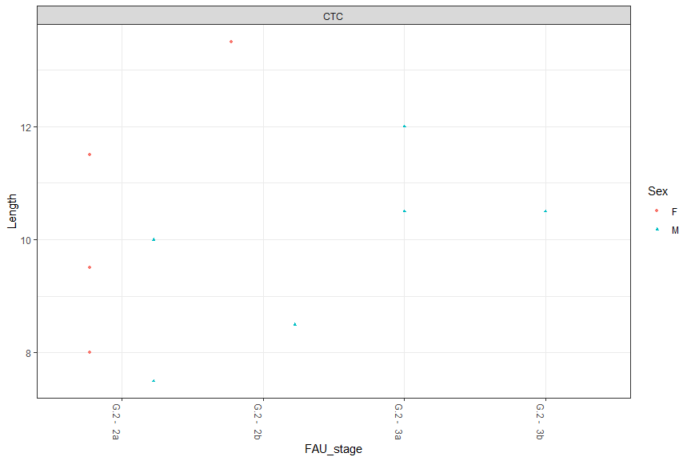

```r
check_lmat_TaskVII.3.2(task_vii32)
```